# Censored Data Analysis

Dennis Helsel and Paul Julian

## Start RStudio

**Caveat:** recently there has been debate on the use and practices surrounding setting a working directory and workflow critiques (see [link](https://www.tidyverse.org/blog/2017/12/workflow-vs-script/)). For purposes of this vignette/training, we will use `setwd()` for simplicity. But honestly, do what works and is comfortable for you. Go forth and code!

### Set the working directory:

Set the working directory to one in which you will save any worksheets or output. In RStudio you can easily do this using RStudio’s pull-down menu: `Session > Set working directory > Choose directory`

or

```r
setwd(".../NADA2")
```

if you are using `setwd()`, for reproducibility it is recommend to use the code above.

### Load Packages

Load the packages needed. Install 15 packages: You can either do this manually via the packages tab by checking the boxes next to the package names or via console/R-script using `install.packages(...)` and `library(...)`.

*Here is a trick to use a list of packages combined with a function that will check if the package is installed, if not install it and then load it.*

```r
check.packages <- function(pkg){
  new.pkg <- pkg[!(pkg %in% installed.packages()[, "Package"])]
  if (length(new.pkg))
    install.packages(new.pkg, dependencies = TRUE)
  sapply(pkg, require, character.only = TRUE)
}

pkg <- c("bestglm","car","cenGAM","EnvStats","fitdistrplus","Kendall",
         "mgcv","multcomp","NADA","nlme","perm","rms","survminer",
         "vegan","NADA2","bestglm")
check.packages(pkg)
```

*Loading libraries using console/R-script*

```r
# Load Package
library(cenGAM)
library(EnvStats)
library(fitdistrplus)
library(Kendall)
library(mgcv)
library(multcomp)
library(NADA)
library(perm)
library(rms)
library(survminer)
library(vegan)
library(NADA2)
library(bestglm)
library(car)
library(nlme)
library(rms)
```

## Loading R Format Databases From Packages

Some packages have datasets contained within them. When you load the packages you have access to those datasets. You can type data() to list all datasets available within the R base packages and in the packages you’ve loaded. Once you know the names of the datasets you want to load, use the data (datasetname) command to load the dataset.

```r
data(Golden); # From NADA package

head(Golden,5L)
```

```
#>   Group Dosage DosageGroup      Liver LiverCen       Bone BoneCen     Brain
#> 1     1      0         Low 0.30164120    FALSE 0.19642727   FALSE 0.3462295
#> 2     1      0         Low 0.13614973    FALSE 0.02902514   FALSE 0.3920635
#> 3     1      0         Low 0.04000000     TRUE 0.03000000    TRUE 0.6950323
#> 4     1      0         Low 0.09892787    FALSE 0.03691224   FALSE 0.1906452
#> 5     1      0         Low 0.04000000     TRUE 0.07664027   FALSE 0.0700000
#>   BrainCen Feather FeatherCen Blood BloodCen     Kidney KidneyCen
#> 1    FALSE   0.070       TRUE  0.02     TRUE 0.08196248     FALSE
#> 2    FALSE   0.060       TRUE  0.02     TRUE 0.06293103     FALSE
#> 3    FALSE   0.394      FALSE  0.02     TRUE 0.05865103     FALSE
#> 4    FALSE   0.111      FALSE  0.02     TRUE 0.09555085     FALSE
#> 5     TRUE   0.242      FALSE  0.02     TRUE 0.11623897     FALSE
```

## Loading External Datasets of Various Formats

For purposes of this vignette, we won’t be loading external dataset, but here is a description of how to load data of several formats from external files.

### Read in an R-format (`.rda`) file.

In the Environment tab, click the open folder icon. Go to the directory where the data are located and choose the file name.

**console/R-script**

```r
dat<-load(".../path/to/data/data.rda")
```

### Read in an excel format (`.xlsx`/`.xls`) file.

In the environment tab, click on the Import Data button. Choose the “From Excel” option. Go to the folder where the data file is located and choose the file name. If there are variable names stored as column names, make sure the box next to First Row as Names is checked, and click Import.

**console/R-script**

There are several R-packages that will read `xlsx` or `xls` files into R. Beware some packages have recod limitations.

```r
library(readxl)
dat <- read_excel(".../path/to/data/data.xlsx",sheet=4)

# or

library(openxlsx)
dat <- read.xlsx(".../path/to/data/data.xlsx",sheet=4)
```

### Read in an csv format (`.csv`) file.

In the environment tab, click on the Import Data button. Choose the “From Text (base)…” option. Go to the folder containing the file and choose the file name. Make sure the Heading button YES is selected if the first row in the dataset are the variable names (text). Change the na.strings entry to whatever in the dataset represents a missing value (often a blank in Excel). Click the Import button.

**console/R-script**

```r
dat <- read.csv(".../path/to/data/data.csv")
```

### Read in an txt format (`.txt`) file.

In the environment tab, click on the Import Data button. Choose the “From Text (base)…” option. Go to the folder containing the data file and choose the file name. Make sure the Heading button YES is selected if the first row in the dataset are the variable names (text). If necessary, change the na.strings entry to whatever in the dataset represents a missing value (often a blank in Excel). Click the Import button.

**console/R-script**

```r
dat <- read.table(".../path/to/data/data.txt")
```

For other data with specific delimiters (i.e. tab delimited) run `?read.table` or `?read.delim` for more info.

## Plotting Censored Data

### Boxplots

*Data: Zinc dataset*

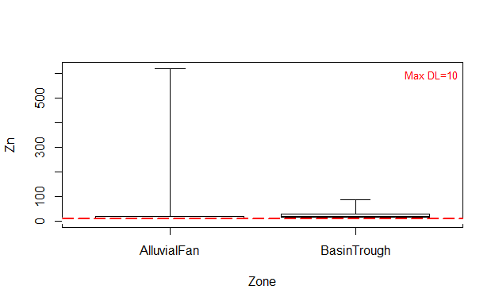

```r
data(CuZn); # Data from the NADA package

cboxplot(CuZn$Zn,CuZn$ZnCen,CuZn$Zone,minmax = TRUE,Xlab="Zone",Ylab="Zn")
```

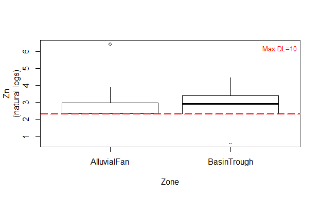

```r
cboxplot(CuZn$Zn,CuZn$ZnCen,CuZn$Zone,LOG=TRUE,Xlab="Zone",Ylab="Zn")
```

Note that without the minmax option, outlier observations such as the one in the Alluvial Fan data, are shown individually.

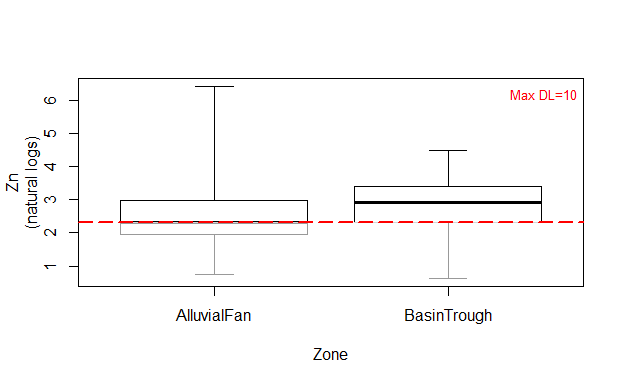

```r
cboxplot(CuZn$Zn,CuZn$ZnCen,CuZn$Zone,LOG=TRUE,show = TRUE, minmax = TRUE,
         Xlab="Zone",Ylab="Zn")
```

The show=TRUE option models the portion of each group’s data below the highest detection limit (the lines in gray) using ROS.

### Scatterplots

*Data: TCE concentrations in ground water*

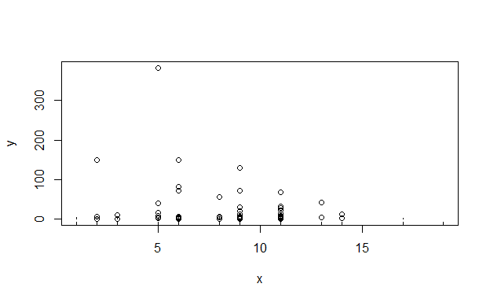

```r
data(TCEReg); # Data from the NADA package

cenxyplot(TCEReg$PopDensity, 1-TCEReg$PopAbv1, TCEReg$TCEConc, TCEReg$TCECen)
```

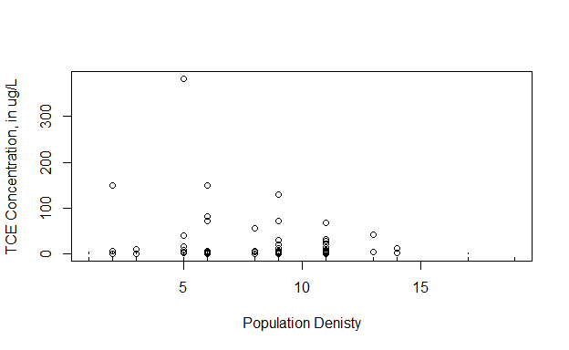

```r
cenxyplot(TCEReg$PopDensity, 1-TCEReg$PopAbv1, TCEReg$TCEConc, TCEReg$TCECen,
          xlab="Population Denisty",ylab="TCE Concentration, in ug/L")
```

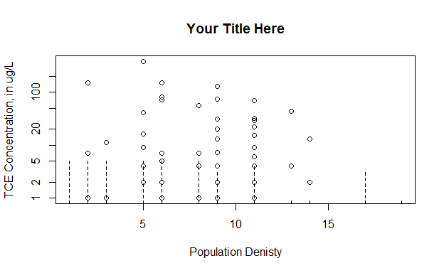

```r
cenxyplot(TCEReg$PopDensity, 1-TCEReg$PopAbv1, TCEReg$TCEConc, TCEReg$TCECen,
          xlab="Population Denisty",ylab="TCE Concentration, in ug/L",
          main = "Your Title Here", log ="y")
```

### Cumulative distribution functions (CDFs)

*Data: Zinc, Pyrene*

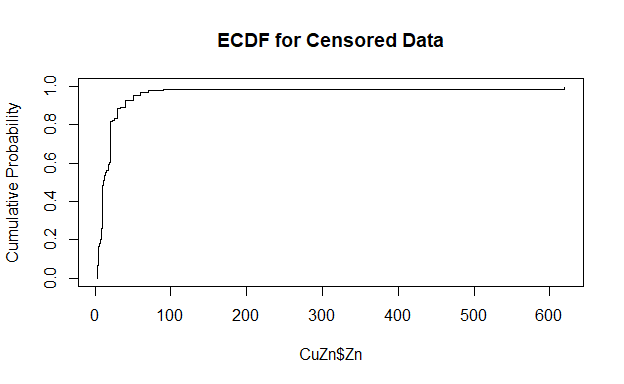

```r
# Data already loaded

cen_ecdf(CuZn$Zn, CuZn$ZnCen)
```

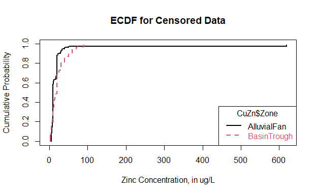

```r
cen_ecdf(CuZn$Zn, CuZn$ZnCen,CuZn$Zone,
         Ylab="Zinc Concentration, in ug/L")
```

#### Compare CDFs

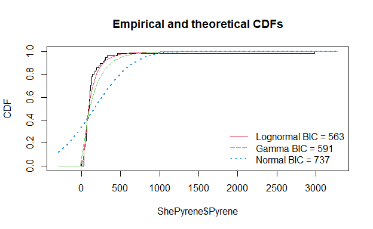

```r
data(ShePyrene); # From the NADA package

cenCompareCdfs(ShePyrene$Pyrene,ShePyrene$PyreneCen)
```

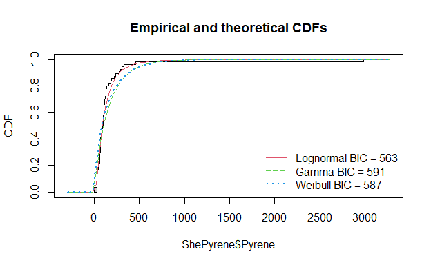

```r
cenCompareCdfs(ShePyrene$Pyrene,ShePyrene$PyreneCen,dist3 = "weibull")
```

### Probability (Q-Q) Plots: Pyrene data

*Data: Pyrene*

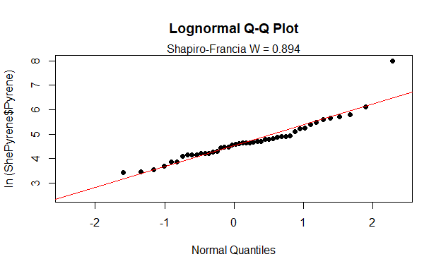

```r
cenQQ(ShePyrene$Pyrene,ShePyrene$PyreneCen)
```

#### Compare QQs

```r
cenCompareQQ(ShePyrene$Pyrene,ShePyrene$PyreneCen,Yname="Pyrene",cex=0.75)
```

```
#> Best of the three distributions is the lognormal
```

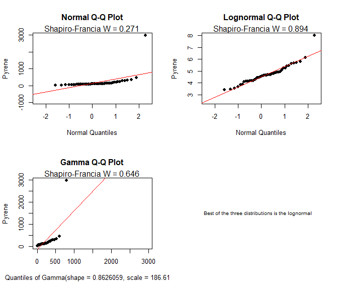

## Estimate Descriptive Statistics

### Exploring the data

In R, the summary command is used to briefly describe the characteristics of the data. In the NADA for R package, the censummary command fulfills the same role for censored data:

```r
censummary(ShePyrene$Pyrene,ShePyrene$PyreneCen)
```

```
#> all:
#>          n      n.cen    pct.cen        min        max
#>   56.00000   11.00000   19.64286   28.00000 2982.00000
#>
#> limits:
#>   limit n uncen   pexceed
#> 1    28 1     3 0.9636368
#> 2    35 2     3 0.8545470
#> 3    58 1    10 0.7818206
#> 4    86 1    11 0.5636411
#> 5   117 1     2 0.3350722
#> 6   122 1     5 0.2947735
#> 7   163 3     1 0.1968254
#> 8   174 1    10 0.1785714
```

There are 11 nondetects located at 8 different detection limits. The probabilities of being less than or equal to the detection limit value is (1-pexceed), one minus the exceedance probability. So the limit at a concentration of 28 is at the (1-0.964), or the 3.6th percentile of the data. And (1-0.179) or 82.1% of the observations are below the highest detection limit of 174.

I’ll demonstrate how to compute MLE, K-M and ROS statistics using both the NADA and EnvStats packages.

### Maximum Likelihood Estimation (MLE)

The cenmle command in the NADA package assumes by default that data follow a *lognormal* distribution. Other distributions may be specified as options. We will use the *lognormal* because it was the best-fitting distribution, as seen in the Plotting Data exercise. The results have been stored as an object `(Pyr.mle.nada`, below) and by typing the object name you get the output.

```r
Pyr.mle.nada <- with(ShePyrene,
                     cenmle(Pyrene,PyreneCen))
Pyr.mle.nada
```

```
#>         n     n.cen    median      mean        sd
#>  56.00000  11.00000  91.64813 133.91419 142.66984
```

The EnvStats package provides different commands for each distribution chosen. As with the plots, *“lnorm”* indicates a *lognormal* distribution, “norm” a normal distribution, and “gamma” a gamma distribution. These come after the *“e”* in the command name. The *“Alt”* in the command tells `EnvStats` to report back the *lognormal* results not in log units, but transformed back into original units. The output is much more detailed than in the `NADA` package. In this example, options for computing two-sided confidence intervals of the mean are specified, which we’ll discuss in the next section of the vignette.

```r
Pyr.mle <- with(ShePyrene,
                elnormAltCensored(Pyrene, PyreneCen,
                             ci=TRUE, ci.method ="bootstrap",
                             n.bootstraps = 5000))
print(Pyr.mle)
```

```
#> $distribution
#> [1] "Lognormal"
#>
#> $sample.size
#> [1] 56
#>
#> $censoring.side
#> [1] "left"
#>
#> $censoring.levels
#> [1]  28  35  58  86 117 122 163 174
#>
#> $percent.censored
#> [1] 19.64286
#>
#> $parameters
#>       mean         cv
#> 133.914189   1.065383
#>
#> $n.param.est
#> [1] 2
#>
#> $method
#> [1] "MLE"
#>
#> $data.name
#> [1] "Pyrene"
#>
#> $censoring.name
#> [1] "PyreneCen"
#>
#> $bad.obs
#> [1] 0
#>
#> $interval
#> $name
#> [1] "Confidence"
#>
#> $parameter
#> [1] "mean"
```

[output cut: 13 more lines]

```
#>
#> $n.bootstraps
#> [1] 5000
#>
#> $too.few.obs.count
#> [1] 0
#>
#> $no.cen.obs.count
#> [1] 0
#>
#> attr(,"class")
#> [1] "intervalEstimateCensored"
#>
#> attr(,"class")
#> [1] "estimateCensored"
```

Using the print statement after storing the output in an object (`Pyr.mle` was used here) produces the table type output shown above. Without the print statement, just typing the object name, the output is generic and not ready to be pasted into a results document.

### Kaplan-Meier

The cenfit function in the `NADA` package has a slightly incorrect detail in its computation of the mean. Here it is, but remember that this issue generally makes the computed mean slightly too high.

```r
Pyr.km.nada <- with(ShePyrene,
                    cenfit(Pyrene, PyreneCen))
Pyr.km.nada
```

```
#>        n    n.cen   median     mean       sd
#>  56.0000  11.0000  98.0000 164.2036 393.9509
```

You should use the `EnvStats` command `enparCensored` instead for Kaplan-Meier, until this issue in the `NADA` package is corrected. The `EnvStats` command uses “npar” for nonparametric to produce the Kaplan-Meier estimates.

```r
Pyr.km <- with(ShePyrene,
                enparCensored(Pyrene, PyreneCen,
                             ci=TRUE, ci.method ="bootstrap",
                             n.bootstraps = 5000))
print(Pyr.km)
```

```
#> $distribution
#> [1] "None"
#>
#> $sample.size
#> [1] 56
#>
#> $censoring.side
#> [1] "left"
#>
#> $censoring.levels
#> [1]  28  35  58  86 117 122 163 174
#>
#> $percent.censored
#> [1] 19.64286
#>
#> $parameters
#>      mean        sd   se.mean
#> 164.09450 389.41379  49.75292
#>
#> $n.param.est
#> [1] 2
#>
#> $method
#> [1] "Kaplan-Meier"
#>
#> $data.name
#> [1] "Pyrene"
#>
#> $censoring.name
#> [1] "PyreneCen"
#>
#> $bad.obs
#> [1] 0
#>
#> $interval
#> $name
#> [1] "Confidence"
#>
#> $parameter
#> [1] "mean"
```

[output cut: 16 more lines]

```
#>
#> $n.bootstraps
#> [1] 5000
#>
#> $too.few.obs.count
#> [1] 0
#>
#> $no.cen.obs.count
#> [1] 0
#>
#> attr(,"class")
#> [1] "intervalEstimateCensored"
#>
#> attr(,"class")
#> [1] "estimateCensored"
```

Note that as with all bootstrap estimates the confidence intervals above will differ slightly from your results.

### Regression on Order Statistics (ROS)

The `cenros` command in the `NADA` package constructs ROS models. The default model fits the data to a *lognormal* distribution. A Q-Q plot is drawn by the plot command using the ROS model. The cenros function will not take data with embedded NA values – manually delete them first or use the `elnormAltCensored` function as in the next section.

```r
Pyr.ROS.nada <- with(ShePyrene,
                     cenros(Pyrene, PyreneCen))
mean(Pyr.ROS.nada)
```

```
#> [1] 163.2494
```

```r
sd(Pyr.ROS.nada)
```

```
#> [1] 393.1068
```

```r
quantile(Pyr.ROS.nada)
```

```
#>        5%       10%       25%       50%       75%       90%       95%
#>  30.78771  33.00000  63.45761  90.50000 132.25000 255.50000 312.75000
```

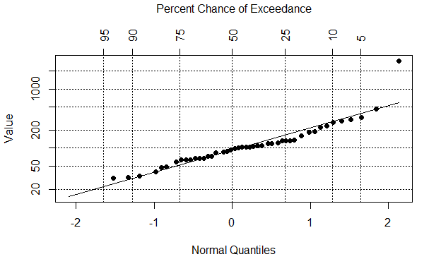

Lognormal probability of pyrene data

```r
plot(Pyr.ROS.nada)
```

The `EnvStats` command is again `elnormAltCensored`, but here with the “rROS” option to compute ROS. In that case the *lognormal* assumption is only for the nondetect data. It also produces confidence intervals for the ROS mean by bootstrapping, making it very useful.

```r
Pyr.ROS <- with(ShePyrene,
                elnormAltCensored(Pyrene, PyreneCen, method="rROS",
                             ci=TRUE, ci.method ="bootstrap",
                             n.bootstraps = 5000))

print(Pyr.ROS)
```

```
#> $distribution
#> [1] "Lognormal"
#>
#> $sample.size
#> [1] 56
#>
#> $censoring.side
#> [1] "left"
#>
#> $censoring.levels
#> [1]  28  35  58  86 117 122 163 174
#>
#> $percent.censored
#> [1] 19.64286
#>
#> $parameters
#>       mean         cv
#> 163.371129   2.406266
#>
#> $n.param.est
#> [1] 2
#>
#> $method
#> [1] "Imputation with                                 Q-Q Regression (rROS)"
#>
#> $data.name
#> [1] "Pyrene"
#>
#> $censoring.name
#> [1] "PyreneCen"
#>
#> $bad.obs
#> [1] 0
#>
#> $interval
#> $name
#> [1] "Confidence"
#>
#> $parameter
#> [1] "mean"
```

[output cut: 13 more lines]

```
#>
#> $n.bootstraps
#> [1] 5000
#>
#> $too.few.obs.count
#> [1] 0
#>
#> $no.cen.obs.count
#> [1] 2
#>
#> attr(,"class")
#> [1] "intervalEstimateCensored"
#>
#> attr(,"class")
#> [1] "estimateCensored"
```

### All at once

Descriptive stats for all three methods, again for the default lognormal distribution, can quickly be produced using the censtats command of the NADA package: Unfortunately this `NADA` package command also cannot currently incorporate `NA` values, so remove them prior to running the command.

```r
with(ShePyrene,censtats(Pyrene, PyreneCen))
```

```
#>        n    n.cen  pct.cen
#> 56.00000 11.00000 19.64286
#>       median     mean       sd
#> K-M 98.00000 164.2036 393.9509
#> ROS 90.50000 163.2494 393.1068
#> MLE 91.64813 133.9142 142.6698
```

K-M and ROS use the high outlier data value to estimate the mean. MLE uses the lognormal model, whose value at that percentile is lower and therefore the MLE estimate of the mean for this dataset is lower. And again, the K-M mean computed in this `NADA` package function is slightly biased high.

## Interval Estimates

Several of the commands to obtain confidence intervals are identical to what we was done in the Estimating Descriptive Statistics section Prediction. and tolerance intervals are new.

### Confidene Intervals

#### Kaplan-Meier

A confidence interval around the KM mean is computed using the enparCensored command. Since K-M is a nonparametric method, the bootstrap method for computing a CI is recommended, as it too requires no assumed distribution. Note that the default CI method is a t-interval, which requires that the distribution of possible estimates of the mean is a normal distribution in order for this confidence interval to be valid. When the sample size is around 70+ this may be a reasonable assumption. For this example it is not. Bootstrap intervals work fine with large and smaller data, say 20 observations and above. First the bootstrap:

```r
## from above
print(Pyr.km)
```

```
#> $distribution
#> [1] "None"
#>
#> $sample.size
#> [1] 56
#>
#> $censoring.side
#> [1] "left"
#>
#> $censoring.levels
#> [1]  28  35  58  86 117 122 163 174
#>
#> $percent.censored
#> [1] 19.64286
#>
#> $parameters
#>      mean        sd   se.mean
#> 164.09450 389.41379  49.75292
#>
#> $n.param.est
#> [1] 2
#>
#> $method
#> [1] "Kaplan-Meier"
#>
#> $data.name
#> [1] "Pyrene"
#>
#> $censoring.name
#> [1] "PyreneCen"
#>
#> $bad.obs
#> [1] 0
#>
#> $interval
#> $name
#> [1] "Confidence"
#>
#> $parameter
#> [1] "mean"
```

[output cut: 16 more lines]

```
#>
#> $n.bootstraps
#> [1] 5000
#>
#> $too.few.obs.count
#> [1] 0
#>
#> $no.cen.obs.count
#> [1] 0
#>
#> attr(,"class")
#> [1] "intervalEstimateCensored"
#>
#> attr(,"class")
#> [1] "estimateCensored"
```

Then the default normal assumption (basically, a t-interval using the K-M estimates of mean and standard deviation):

```r
Pyr.km2 <- with(ShePyrene,enparCensored(Pyrene,PyreneCen, ci=TRUE))

print(Pyr.km2)
```

```
#> $distribution
#> [1] "None"
#>
#> $sample.size
#> [1] 56
#>
#> $censoring.side
#> [1] "left"
#>
#> $censoring.levels
#> [1]  28  35  58  86 117 122 163 174
#>
#> $percent.censored
#> [1] 19.64286
#>
#> $parameters
#>      mean        sd   se.mean
#> 164.09450 389.41379  49.75292
#>
#> $n.param.est
#> [1] 2
#>
#> $method
#> [1] "Kaplan-Meier"
#>
#> $data.name
#> [1] "Pyrene"
#>
#> $censoring.name
#> [1] "PyreneCen"
#>
#> $bad.obs
#> [1] 0
#>
#> $interval
#> $name
#> [1] "Confidence"
#>
#> $parameter
#> [1] "mean"
#>
#> $limits
#>       LCL       UCL
#>  66.58057 261.60844
#>
#> $type
#> [1] "two-sided"
#>
#> $method
#> [1] "Normal Approximation"
#>
#> $conf.level
#> [1] 0.95
#>
#> attr(,"class")
#> [1] "intervalEstimate"
#>
#> attr(,"class")
#> [1] "estimateCensored"
```

This t-interval (Normal Approximation) LCL goes down considerably lower (66.5) than the BCa bootstrap interval (98.3) because the t-interval must be symmetric, and the upper end is approx. 100 ug/L above the mean, so the LCL must be 100 below the mean. The data don’t warrant that low of an interval as they are asymmetric, and the bootstrap LCL picks up on that information.

#### MLE

Computing the mean of an cenmle object also gives its confidence interval:

```r
pymle <- with(ShePyrene,cenmle(Pyrene, PyreneCen,conf.int=0.95))

mean(pymle)
```

```
#>      mean        se   0.95LCL   0.95UCL
#> 133.91419  19.06506 102.51010 174.93895
```

These assume the default *lognormal* distribution. Change the `conf.int=` value to get an interval with something other than the default 0.95 confidence coefficient. To get the more typical normal distribution interval, use the `dist="gaussian"` option.

```r
pymlenorm <- with(ShePyrene,cenmle(Pyrene, PyreneCen, dist="gaussian"))

mean(pymlenorm)
```

```
#>      mean        se   0.95LCL   0.95UCL
#> 163.09649  52.14325  60.89759 265.29538
```

A better method for computing confidence intervals and bounds for skewed data would be bootstrapping. This is the option we used in the Descriptive Statistics exercise above. For the *lognormal* MLE method:

```r
pyr.lnorm <- with(ShePyrene,
                  elnormAltCensored(Pyrene, PyreneCen,
                                    ci=TRUE, ci.method ="bootstrap",
                                    n.bootstraps = 5000))

print(pyr.lnorm)
```

```
#> $distribution
#> [1] "Lognormal"
#>
#> $sample.size
#> [1] 56
#>
#> $censoring.side
#> [1] "left"
#>
#> $censoring.levels
#> [1]  28  35  58  86 117 122 163 174
#>
#> $percent.censored
#> [1] 19.64286
#>
#> $parameters
#>       mean         cv
#> 133.914189   1.065383
#>
#> $n.param.est
#> [1] 2
#>
#> $method
#> [1] "MLE"
#>
#> $data.name
#> [1] "Pyrene"
#>
#> $censoring.name
#> [1] "PyreneCen"
#>
#> $bad.obs
#> [1] 0
#>
#> $interval
#> $name
#> [1] "Confidence"
#>
#> $parameter
#> [1] "mean"
```

[output cut: 13 more lines]

```
#>
#> $n.bootstraps
#> [1] 5000
#>
#> $too.few.obs.count
#> [1] 0
#>
#> $no.cen.obs.count
#> [1] 0
#>
#> attr(,"class")
#> [1] "intervalEstimateCensored"
#>
#> attr(,"class")
#> [1] "estimateCensored"
```

#### ROS

The `cenros` command in `NADA` does not compute confidence intervals for the mean. Use the `EnvStats` command `elnormAltCensored` as done previously in the Descriptive Statistics exercise to bootstrap a confidence interval for the ROS method.

```r
# from above
print(Pyr.ROS)
```

```
#> $distribution
#> [1] "Lognormal"
#>
#> $sample.size
#> [1] 56
#>
#> $censoring.side
#> [1] "left"
#>
#> $censoring.levels
#> [1]  28  35  58  86 117 122 163 174
#>
#> $percent.censored
#> [1] 19.64286
#>
#> $parameters
#>       mean         cv
#> 163.371129   2.406266
#>
#> $n.param.est
#> [1] 2
#>
#> $method
#> [1] "Imputation with                                 Q-Q Regression (rROS)"
#>
#> $data.name
#> [1] "Pyrene"
#>
#> $censoring.name
#> [1] "PyreneCen"
#>
#> $bad.obs
#> [1] 0
#>
#> $interval
#> $name
#> [1] "Confidence"
#>
#> $parameter
#> [1] "mean"
```

[output cut: 13 more lines]

```
#>
#> $n.bootstraps
#> [1] 5000
#>
#> $too.few.obs.count
#> [1] 0
#>
#> $no.cen.obs.count
#> [1] 2
#>
#> attr(,"class")
#> [1] "intervalEstimateCensored"
#>
#> attr(,"class")
#> [1] "estimateCensored"
```

Generally, I recommend using a bootstrap estimate when there is sufficient data, which there are here, as theoretical methods such as Cox are strongly dependent on the *lognormal* shape that often does not fit exactly. Remember, ROS assumes a distribution but only for the censored observations.

### Prediction Intervals

Intervals for computing the range of probable values for new observations when the data distribution has not changed can be quickly performed using MLE for three assumed distributions using the cenPredInt command:

```r
with(ShePyrene,cenPredInt(Pyrene, PyreneCen))
```

```
#> 95% Prediction Limits
#>   Distribution      95% LPL  95% UPL
#> 1    Lognormal   15.7540607 533.1565
#> 2        Gamma    0.7231388 581.0615
#> 3       Normal -783.7555461 992.1820
```

The default intervals here are for 1 new observation. That can be changed with the `newobs =`option. See NADA2 package. You can ignore the warnings about NAs in the dataset, they are deleted prior to computing the intervals, just as you would by hand if necessary.

The same function can be used to compute PIs using ROS, here for 2 new observations, which will make them wider than the intervals for 1 new observation above:

```r
with(ShePyrene,cenPredInt(Pyrene, PyreneCen,newobs =2, method = "rROS"))
```

```
#> 95% Prediction Limits
#>   Distribution      95% LPL   95% UPL
#> 1    Lognormal   13.0468382  667.8651
#> 2        Gamma    0.1274249  692.7938
#> 3       Normal -817.2081679 1093.6174
```

The normal distribution is this example is not a good fit, as shown by the negative value of the lower 95% prediction intervals when assuming a normal distribution.

### Tolerance Intervals

Intervals for computing an upper bound on the true X% percentile, to state that we are 95% confident that no more than (1-X%) of data will exceed it, are computed using MLE by:

(Here for the 90th percentile – no more than 10% exceedances).

To compute a tolerance interval for three distributions, plus a graph showing BIC stats to determine which is best (lowest BIC is best), use the `cenTolInt` function in the `NADA2` package:

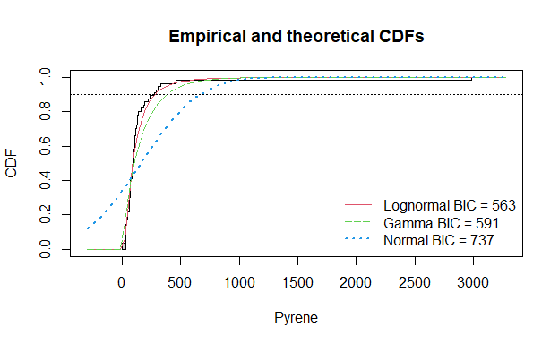

```
#>   Distribution 90th Pctl  95% UTL      BIC Method
#> 1    Lognormal  279.7995 376.4538 563.1224    mle
#> 2        Gamma  340.2525 440.4870 591.4928    mle
#> 3       Normal  667.0507 816.6821 737.2320    mle
```

```r
with(ShePyrene,cenTolInt(Pyrene, PyreneCen, cover=0.9))
```

What’s inside this function? If you would like info on the commands this function uses, its below. If that’s not your thing, just use the function! Here’s how you would get the lognormal tolerance interval:

```r
example <- with(ShePyrene,
            eqlnormCensored (Pyrene, PyreneCen, p=0.9,
                             ci=TRUE, ci.type ="upper"))
print(example)
```

```
#> $distribution
#> [1] "Lognormal"
#>
#> $sample.size
#> [1] 56
#>
#> $censoring.side
#> [1] "left"
#>
#> $censoring.levels
#> [1]  28  35  58  86 117 122 163 174
#>
#> $percent.censored
#> [1] 19.64286
#>
#> $parameters
#>   meanlog     sdlog
#> 4.5179565 0.8709106
#>
#> $n.param.est
#> [1] 2
#>
#> $method
#> [1] "MLE"
#>
#> $data.name
#> [1] "Pyrene"
#>
#> $censoring.name
#> [1] "PyreneCen"
#>
#> $bad.obs
#> [1] 0
#>
#> $quantiles
#> 90'th %ile
#>   279.7995
#>
#> $quantile.method
#> [1] "Quantile(s) Based on\n                                 MLE Estimators"
```

[output cut: 17 more lines]

```
#>
#> $conf.level
#> [1] 0.95
#>
#> $sample.size
#> [1] 56
#>
#> $dof
#> [1] 55
#>
#> attr(,"class")
#> [1] "intervalEstimateCensored"
#>
#> attr(,"class")
#> [1] "estimateCensored"
```

Here’s how you would compute a gamma tolerance interval by first taking cube roots, then using those in a censored normal routine to get a tolerance interval on a percentile, then retransforming back to the original data scale by cubing the result:

```r
dat.gamma <- ShePyrene$Pyrene^(1/3)

obj.gamma <- eqnormCensored(dat.gamma, ShePyrene$PyreneCen, p=0.9,
                            ci=TRUE, ci.type ="upper")
pct.gamma <- obj.gamma$quantiles^3 # the 90th percentile in orig units
pct.gamma
```

```
#> 90'th %ile
#>   340.2525
```

```r
ti.gamma <- (obj.gamma$interval$limits[2])^3 # the upper tol limit in orig units
ti.gamma
```

```
#>     UCL
#> 440.487
```

This agrees with the output of the `cenTolInt` command used above, where the results for a gamma distribution are printed.

## Matched Pair Tests and Comparing Data to Standards

### Compare Data to a Standard Using a Matched Pair Test

**Example 1:** Use the `cen_paired` function to determine if arsenic concentrations in groundwater exceed the drinking water standard of 10 ug/L standard for the Example1 dataset.

```r
data(Example1) # From NADA2 package

head(Example1,5L)
```

```
#>   Arsenic NDis1 NDisTRUE
#> 1 4.00000     1     TRUE
#> 2 4.20000     0    FALSE
#> 3 0.61606     0    FALSE
#> 4 5.27628     0    FALSE
#> 5 3.00000     1     TRUE
```

```r
with(Example1,cen_paired(Arsenic, NDisTRUE, 10, alt = "greater"))
```

```
#>  Censored paired test for mean(Arsenic) equals 10
#>  alternative hypothesis: true mean Arsenic exceeds 10.
#>
#>  n = 21   Z= -20.4157   p-value = 1
#>  Mean Arsenic = 2.252
```

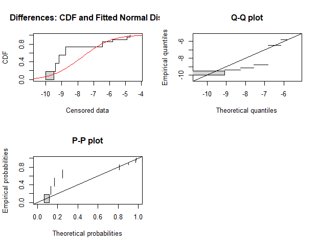

The mean arsenic concentration does not exceed 10 ug/L.

### Test for Differences in Two Paired Columns of Data

**Example 2:** Test whether atrazine concentrations were the same in June versus September groundwaters on the same dates in a variety of wells (rows – paired data). Test both for differences in the mean as well as differences in the cdfs and the medians.

```r
data(Atra); # From NADA package

head(Atra,5L)
```

```
#>   June Sept JuneCen SeptCen
#> 1 0.38 2.66   FALSE   FALSE
#> 2 0.04 0.63   FALSE   FALSE
#> 3 0.01 0.59    TRUE   FALSE
#> 4 0.03 0.05   FALSE   FALSE
#> 5 0.03 0.84   FALSE   FALSE
```

```r
with(Atra,cen_paired(June, JuneCen, Sept, SeptCen))
```

```
#> Censored paired test for mean(June - Sept) equals 0.
#>  alternative hypothesis: true mean difference does not equal 0.
#>
#>  n = 24   Z= -1.0924   p-value = 0.2747
#>  Mean difference = -3.927
```

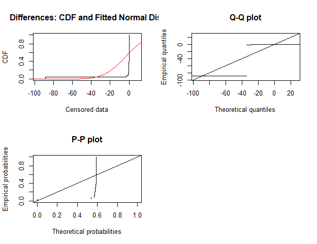

The p-value is well above 0.05. Do not reject that the mean difference in concentration for the two months could be 0.

```r
# test for the median difference = 0 using the sign test.
with(Atra,cen_signtest(June, JuneCen, Sept, SeptCen))
```

```
#> Censored sign test for median(x:June - y:Sept) equals 0
#>    alternative hypothesis: true median difference is not = 0
#>    n = 24   n+ = 3   n- = 16    ties: 5
#>
#>   No correction for ties:   p-value = 0.004425
#> Fong correction for ties:   p-value = 0.08956
```

Because it is important to correct for the numbers of tied values within a pair, the p-value of 0.089 results in the conclusion to not reject that the median difference in concentration between the two months could be 0.

```r
# test for a difference in the cdfs of the two months using the signed-rank
with(Atra,cen_signedranktest(June, JuneCen, Sept, SeptCen))
```

```
#> Censored signed-rank test for (x:June - y:Sept) equals 0
#> alternative hypothesis: true difference June - Sept does not equal 0
#>
#>  Pratt correction for ties
#> n = 24, Z = -3.319, p.value = 0.0009033
```

The signed-rank test has more power to see differences than did the sign test. It also is comparing the cdfs, the entire set of percentiles, between the two months. It finds a difference because the upper end of the distribution is quite a bit higher in the Sept data.

### Comparing Data to Standards Using an Upper Confidence Limit

Using the Example 1 data, compute the UCL95 for censored data.

**Step 1.** Sample size. There are 21 observations. Since it is on the borderline for deciding whether to use a distributional or nonparametric method, both will be demonstrated here.

**Step 2. Distributional Method**

Draw the boxplot for “censored data” (data with nondetects).

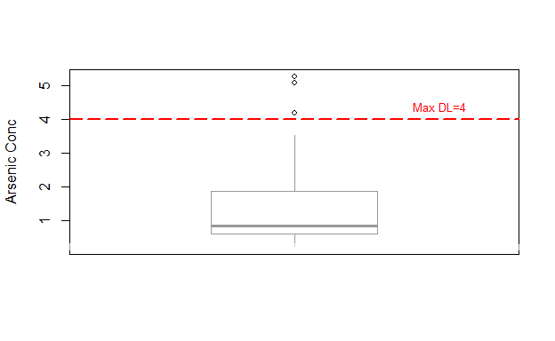

```r
with(Example1,
     cboxplot(Arsenic, NDisTRUE, Ylab="Arsenic Conc", show = TRUE))
```

Note that the highest detection limit is drawn as the horizontal dashed line at 4 ug/L. Everything below that includes values estimated using a lognormal ROS. Three “outliers” (not ‘bad data’) lie above the estimated whisker, showing that the data are skewed.

Decide which of three distributions best fits the data using the `cenCompareCdfs` command. Choose the distribution with the smallest BIC.

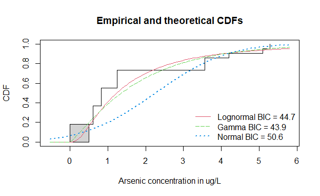

```r
with(Example1,
     cenCompareCdfs (Arsenic, NDisTRUE, Yname = "Arsenic concentration in ug/L"))
```

The gamma distribution has the smallest BIC.

Note that the curve representing the normal distribution dips below zero (x=0) at about the 10th percentile. A distribution of concentrations with 10% negative numbers is not realistic, which results in a higher BIC statistic.

Use the best-fit distribution (gamma) from 2b to compute the UCL95.

```r
egam <- with(Example1,
             egammaAltCensored(Arsenic, NDisTRUE,
                               ci=TRUE, ci.type = "upper",
                               ci.method = "normal.approx"))
print(egam)
```

```
#> $distribution
#> [1] "Gamma"
#>
#> $sample.size
#> [1] 21
#>
#> $censoring.side
#> [1] "left"
#>
#> $censoring.levels
#> [1] 0.5 2.0 3.0 4.0
#>
#> $percent.censored
#> [1] 66.66667
#>
#> $parameters
#>      mean        cv
#> 1.8399269 0.9131572
#>
#> $n.param.est
#> [1] 2
#>
#> $method
#> [1] "MLE"
#>
#> $data.name
#> [1] "Arsenic"
#>
#> $censoring.name
#> [1] "NDisTRUE"
#>
#> $bad.obs
#> [1] 0
#>
#> $interval
#> $name
#> [1] "Confidence"
#>
#> $parameter
#> [1] "mean"
#>
#> $limits
#>      LCL      UCL
#>     -Inf 2.575537
#>
#> $type
#> [1] "upper"
#>
#> $method
#> [1] "Normal Approximation"
#>
#> $conf.level
#> [1] 0.95
#>
#> attr(,"class")
#> [1] "intervalEstimate"
#>
#> attr(,"class")
#> [1] "estimateCensored"
```

Use the print statement to get the “table format” for the output from this EnvStats function. The UCL95 equals 2.57 assuming a gamma distribution. Because this is lower than the 10 ug/L standard, the null hypothesis of non-compliance is rejected, and the site from which these data came is found to be in compliance.

**Step 3. Nonparametric Method**

**Example 1:**

There are multiple detection limits for this arsenic data. Compute the Kaplan-Meier estimate of the mean and percentile bootstrap UCL95, the latter because of the high percent of nondetects (66.67%) in the data.

```r
arsenic.out <- with(Example1,
                    enparCensored(Arsenic, NDisTRUE,
                                  ci=TRUE, ci.method="bootstrap", ci.type="upper",
                                  n.bootstraps=5000))
print(arsenic.out)
```

```
#> $distribution
#> [1] "None"
#>
#> $sample.size
#> [1] 21
#>
#> $censoring.side
#> [1] "left"
#>
#> $censoring.levels
#> [1] 0.5 2.0 3.0 4.0
#>
#> $percent.censored
#> [1] 66.66667
#>
#> $parameters
#>      mean        sd   se.mean
#> 1.7169702 1.5928374 0.1159666
#>
#> $n.param.est
#> [1] 2
#>
#> $method
#> [1] "Kaplan-Meier"
#>
#> $data.name
#> [1] "Arsenic"
#>
#> $censoring.name
#> [1] "NDisTRUE"
#>
#> $bad.obs
#> [1] 0
#>
#> $interval
#> $name
#> [1] "Confidence"
#>
#> $parameter
#> [1] "mean"
```

[output cut: 16 more lines]

```
#>
#> $n.bootstraps
#> [1] 5000
#>
#> $too.few.obs.count
#> [1] 11
#>
#> $no.cen.obs.count
#> [1] 0
#>
#> attr(,"class")
#> [1] "intervalEstimateCensored"
#>
#> attr(,"class")
#> [1] "estimateCensored"
```

The percentile bootstrap estimate of the UCL95 will be near to 2.53, with the output varying slightly each time a bootstrap estimate is run. This is essentially the same estimate as that for the gamma distribution, with the identical result – the site is found to be in compliance.

**Example 2:** Computation of a UCL95 for data with both detected and non-detected values, DL unknown.

Data: Methyl Isobutyl Ketone (MIBK) in air above a medium-sized US city.

```r
data(Example2)
```

*A: Computation of the mean and UCL95*

The MIBK concentrations are given as reported in column 1 – no detection limit was provided. Nondetects were designated only as ND. The lowest detected value in the data equals 0.1229. Assuming all ND values are lower than this, all NDs were changed to <0.1229 as shown in the MIBK and MIBKcen columns.

This results in only one reporting limit in the data, so the Kaplan-Meier estimate will be biased a bit high. Instead, use the robust ROS method with bootstrapping:

```r
mibk.ucl95 <- with(Example2,
                   elnormAltCensored (MIBK, MIBKcen, method = "rROS",
                                      ci=TRUE, ci.method = "bootstrap",
                                      ci.type = "upper", n.bootstraps = 5000))
print(mibk.ucl95)
```

```
#> $distribution
#> [1] "Lognormal"
#>
#> $sample.size
#> [1] 31
#>
#> $censoring.side
#> [1] "left"
#>
#> $censoring.levels
#> [1] 0.1229
#>
#> $percent.censored
#> [1] 48.3871
#>
#> $parameters
#>      mean        cv
#> 0.2160198 0.9338747
#>
#> $n.param.est
#> [1] 2
#>
#> $method
#> [1] "Imputation with\n                                 Q-Q Regression (rROS)"
#>
#> $data.name
#> [1] "MIBK"
#>
#> $censoring.name
#> [1] "MIBKcen"
#>
#> $bad.obs
#> [1] 0
#>
#> $interval
#> $name
#> [1] "Confidence"
#>
#> $parameter
#> [1] "mean"
```

[output cut: 13 more lines]

```
#>
#> $n.bootstraps
#> [1] 5000
#>
#> $too.few.obs.count
#> [1] 0
#>
#> $no.cen.obs.count
#> [1] 0
#>
#> attr(,"class")
#> [1] "intervalEstimateCensored"
#>
#> attr(,"class")
#> [1] "estimateCensored"
```

The percentile bootstrap UCL95 based on the robust ROS mean equals 0.290 (the Kaplan-Meier estimate with the slight bias would have equaled 0.293). Remember that your bootstrap result will slightly differ from the one here. To decrease differences between runs, increase the number of bootstraps, say to 10,000.

*B: What if the detection limit had been known?*

If a reporting limit of 0.029 had been provided by the laboratory, the data would be as given in the MIBK2 and MIBK2cen columns. Using the same procedure gives slightly lower results for both mean and UCL95:

```r
mibk2.out <- with(Example2,
                  elnormAltCensored (MIBK2, MIBK2cen, method = "rROS",
                                     ci=TRUE, ci.method = "bootstrap",
                                     ci.type = "upper", n.bootstraps = 5000))
print(mibk2.out)
```

```
#> $distribution
#> [1] "Lognormal"
#>
#> $sample.size
#> [1] 31
#>
#> $censoring.side
#> [1] "left"
#>
#> $censoring.levels
#> [1] 0.029
#>
#> $percent.censored
#> [1] 48.3871
#>
#> $parameters
#>      mean        cv
#> 0.2146941 0.9436391
#>
#> $n.param.est
#> [1] 2
#>
#> $method
#> [1] "Imputation with\n                                 Q-Q Regression (rROS)"
#>
#> $data.name
#> [1] "MIBK2"
#>
#> $censoring.name
#> [1] "MIBK2cen"
#>
#> $bad.obs
#> [1] 0
#>
#> $interval
#> $name
#> [1] "Confidence"
#>
#> $parameter
#> [1] "mean"
```

[output cut: 13 more lines]

```
#>
#> $n.bootstraps
#> [1] 5000
#>
#> $too.few.obs.count
#> [1] 0
#>
#> $no.cen.obs.count
#> [1] 0
#>
#> attr(,"class")
#> [1] "intervalEstimateCensored"
#>
#> attr(,"class")
#> [1] "estimateCensored"
```

The percentile bootstrap UCL95 based on the robust ROS mean will be near to 0.290 with this known detection limit. It is always better to use the laboratory documented limit, but not having one should not stop the user from computing estimates using the lowest detected observation as the limit.

**Example 3:** Computation of the expected percent of observations exceeding a health advisory when all data are NDs. More details of this method are found in Chapter 8 of Statistics for Censored Environmental Data Using Minitab and R (Helsel, 2012).

```r
data(Example3)
```

All detection limits used are below the 10 ppb drinking water MCL for arsenic. Therefore we know that 0 out of 14 current observations exceed the MCL of 10 ppb. What is the range of percent of observations in the aquifer that might exceed the MCL (with 95% probability)? Use the binomial test command, entering the number of observations in the dataset that exceed the MCL (0) and the number of total observations (14). The `alternative =”less”` option states that this is a one-sided confidence interval – we are looking only for possible exceedances, nothing on the low end.

```r
binom.test(0,14,alternative="less")
```

```
#>
#>  Exact binomial test
#>
#> data:  0 and 14
#> number of successes = 0, number of trials = 14, p-value = 6.104e-05
#> alternative hypothesis: true probability of success is less than 0.5
#> 95 percent confidence interval:
#>  0.0000000 0.1926362
#> sample estimates:
#> probability of success
#>                      0
```

Most of what is returned concerns a test for whether the proportion of observations above the MCL differs from 50%, but this test is of no interest here. What is of interest is the confidence interval on the proportion of observations in the population that could be above the MCL, based on the 14 samples observed. The UCL95 of the proportion equals 0.192. Therefore we can say with 95% probability that there are no more than 19.2% of concentrations in the aquifer exceeding the MCL – we expect that there are fewer because the MCL of 10 is considerably above the highest detection limit of 4 ppb, and this interval is actually the probability of exceeding 4 ppb. Taking this conservative approach that the probability of values falling above 4 ppb is the same probability of falling above 10 ppb, the expected percent of samples at this location above the MCL of 10 ppb is no more than 19.2%. This range could be tightened by taking more samples, of course. For other questions that can be answered when all values are nondetects, see Chapter 8 in Helsel (2012).

## Two-Group Tests

The MLE version of a “t-test” for censored data uses an MLE regression with one X variable, a 0/1 group indicator. Assuming a normal distribution:

```r
with(CuZn,cen2means(Zn,ZnCen,Zone,LOG=FALSE))
```

```
#>      MLE 't-test' of mean CensData: Zn   by Factor: Zone
#>      Assuming normal distribution of residuals around group means
#>      mean of AlluvialFan = 11.49     mean of BasinTrough = 18.13
#>      Chisq = 0.2928  on 1 degrees of freedom     p = 0.588
#> Warning in cen2means(Zn, ZnCen, Zone, LOG = FALSE): NOTE: Data with nondetects may be projected below 0 with MLE normal distribution.
#>    If so, p-values will be unreliable (often too small).  Use perm test instead.
```

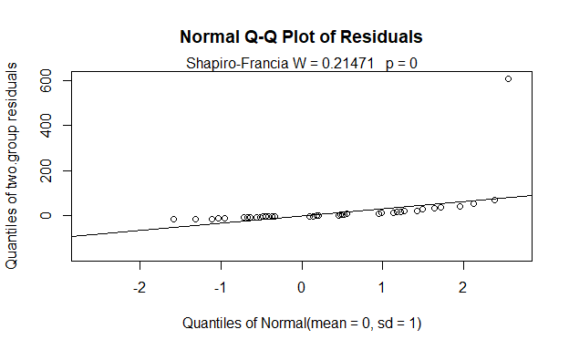

No difference between group means can be seen. But do the residuals follow a normal distribution, as required? The corresponding Q-Q plot of regression residuals and corresponding Shapiro-Francia test show that the data do not follow a normal distribution.

MLE also builds a model of the two groups after estimating their mean and standard deviations. When assuming a normal distribution with data close to zero it is easy for the model to project data down below zero. Besides being unrealistic, this can lead to a false separation between the groups and p-values that are too low. To avoid this, either assume a lognormal distribution (the default, or use LOG=TRUE) or use a permutation test instead.

Use the cenperm2 function to perform a two-group permutation test. This avoids an assumption of a normal distribution while testing for differences in means:

```r
with(CuZn,cenperm2(Zn,ZnCen,Zone))
```

```
#>  Permutation test of mean CensData: Zn   by Factor: Zone
#>      9999 Permutations     alternative = two.sided
#>   mean of AlluvialFan = 21.22 to 23.51     mean of BasinTrough = 21.28 to 21.94
#>      Mean (AlluvialFan - BasinTrough) =  -0.05612 to 1.567       p = 1 to 0.9991
#>
```

The two groups do not have significantly different means. These are p-values that you can believe, as they do not depend on the normal assumption and do not project data values below zero.

Using cen2means to perform the test using the default lognormal distribution, the difference in geometric means (not arithmetic means) is performed below.

```r
with(CuZn,cen2means(Zn,ZnCen,Zone))
```

```
#>      MLE 't-test' of mean natural logs of CensData: Zn by Factor: Zone
#>      Assuming lognormal distribution of residuals around group geometric means
#>      geometric mean of AlluvialFan = 11.78     geometric mean of BasinTrough = 15.24
#>      Chisq = 2.547  on 1 degrees of freedom     p = 0.11
#>
```

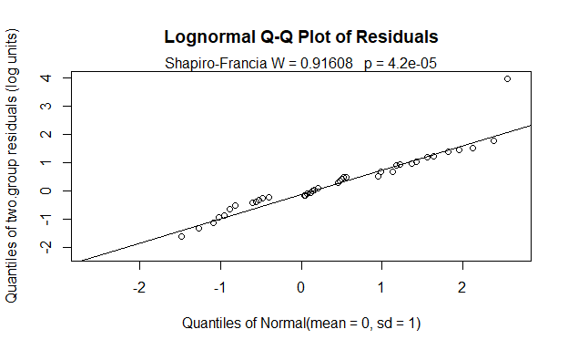

No significant difference between geometric means. And the corresponding Q-Q plot of regression residuals show that the data do not follow a lognormal distribution either (one large outlier), but it is the better fit of the two distributions. A permutation test using cenperm2 after computing the logarithms would be a better test for differences in geometric means.

“A nonparametric test between the two groups will test differences between their cdfs (often considered as a test for difference in medians) instead of testing the difference between means. The Peto-Peto test is run using the cen1way function. It reports the Kaplan-Meier medians in each of the groups:

```r
with(CuZn,cen1way(Zn,ZnCen,Zone))
```

```
#>             grp    N   PctND   KMmean    KMsd   KMmedian
#> 1   AlluvialFan   67   23.88    22.70   74.03         10
#> 2   BasinTrough   50    8.00    21.61   18.77         20
#>
#>       Oneway Peto-Peto test of CensData: Zn   by Factor: Zone
#>       Chisq = 5.183   on 1 degrees of freedom     p = 0.0228
```

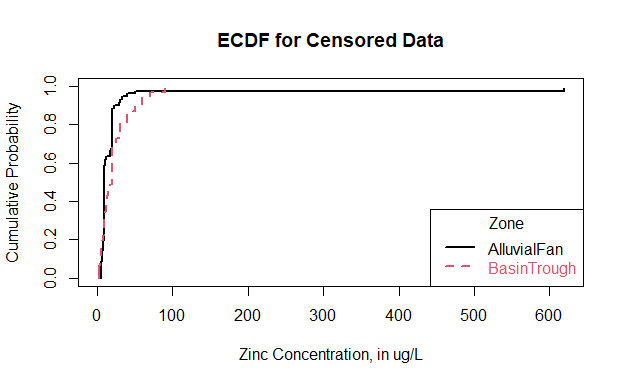

```r
with(CuZn,cen_ecdf (Zn,ZnCen,Zone,
                    Ylab="Zinc Concentration, in ug/L"))
```

Above approximately the 40th percentile or so, the Basin Trough (dashed line) data are higher than (to the right of) the Alluvial Fan data. Boxplots might show the group differences better than do the cdfs, especially for non-statisticians.

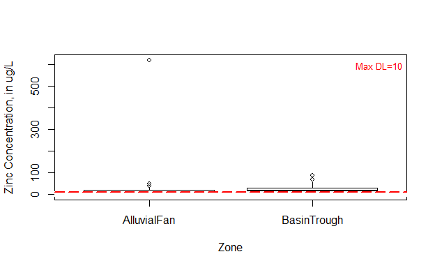

```r
with(CuZn,cboxplot(Zn,ZnCen,Zone,
                    Ylab="Zinc Concentration, in ug/L"))
```

Now for the two simpler tests, where all values below the highest DL must be re-censored.

Contingency tables are a test to determine whether the proportions of data in categories are the same in two or more groups. With nondetects the cutoff level is again the highest reporting limit. Use the `TCE2` dataset with the highest of 4 DLs at 5 ug/L. The test determines whether the proportions of data above versus below the cutoff are the same in each group. It differs from a rank-sum in that all data above the limit are simply in the same ‘Above’ group rather than ranked individually. This loses some information as compared to the rank-sum test. Density is a text variable (a factor) representing the groups, while Below5Cens has a 1 for data below 5 ug/L and a 0 for data at or above 5. First we combine them into a matrix using the ftable command, then compute a ‘cross-tabulation’ with the `xtabs(...)` command that the `chisq.test(...)` command expects. Finally the chisquare test is computed. Its null hypothesis is that there is no difference in the percent of data above the cutoff of 5 ug/L in the two groups.

```r
data(TCE2)

with(TCE2,ftable(Density~Below5Cens))
```

```
#>            Density High Medium
#> Below5Cens
#> 0                    18     12
#> 1                    74    118
```

```r
tab=with(TCE2,xtabs(~Below5Cens+Density))
chisq.test(tab)
```

```
#>
#>  Pearson's Chi-squared test with Yates' continuity correction
#>
#> data:  tab
#> X-squared = 4.0785, df = 1, p-value = 0.04343
```

The contingency table finds a difference in the proportions. It is less powerful than the rank-sum test (which will also find a difference) when there are data that can be ranked above the highest reporting limit.

The nonparametric Wilcoxon rank-sum test can be calculated using the `wilcox.test(...)` command. First you must have or create a column that contains the concentrations for all detected values at the maxDL and above, plus a single number (I use -1) below the max DL for all values below the maxDL.

```r
TCE2$Below5[TCE2$Below5Cens== 1] <- -1      # all <5s are now a -1

wilcox.test(Below5~Density,TCE2)
```

```
#>
#>  Wilcoxon rank sum test with continuity correction
#>
#> data:  Below5 by Density
#> W = 6599.5, p-value = 0.02713
#> alternative hypothesis: true location shift is not equal to 0
```

The two-sided p-value is significant at 0.027. The smaller p-value than the contingency table test reflects the additional information in the individual values at and above 5 that the rank-sum tests uses. The slightly smaller p-value for the Peto-Peto test shows that it is the most appropriate test when there are multiple detection limits.

Is re-censoring at the highest DL and running the rank-sum test really better than the typical method of running a t-test on data with one-half DL subbed for nondetects?

```r
t.test(Half.DL~Density,TCE2)
```

```
#>
#>  Welch Two Sample t-test
#>
#> data:  Half.DL by Density
#> t = -0.065623, df = 201.88, p-value = 0.9477
#> alternative hypothesis: true difference in means between group High and group Medium is not equal to 0
#> 95 percent confidence interval:
#>  -8.073324  7.553257
#> sample estimates:
#>   mean in group High mean in group Medium
#>             7.763043             8.023077
```

No significant difference found. The arbitrariness of the substitution process, not to mention that this puts the same number in many times, and so likely decreases the standard deviation artificially, should get you to quickly use a nonparametric test instead.

## Three or more groups

The `Golden` data present lead concentrations in organs of herons after exposing them to lead. There are four dosage groups (“Dosage” or “Group” columns), zero plus three amounts of lead. The objective was to determine if feathers or another non-destructive part of the birds could be used as an environmental indicator, so it would not be necessary to sacrifice a bird in order to measure their lead concentrations. A censored boxplot of the Golden liver lead data shows that the third and fourth groups have generally higher values.

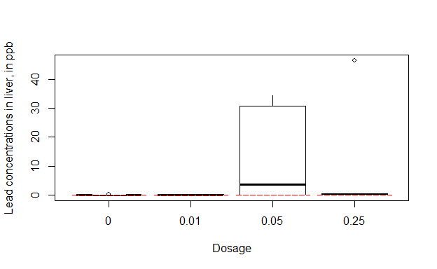

```r
data(Golden)

with(Golden,cboxplot(Liver, LiverCen, Dosage,
                     Ylab = "Lead concentrations in liver, in ppb"))
```

The skewness of the 0.05 group and the outlier of the 0.25 group indicates that logs should end up being the better set of units to use.

### Kruskal-Wallis test

First the groups can be compared using a Kruskal-Wallis test, setting all values below the highest detection limit of 0.04 as tied. Note that there are detected observations below 0.04, so either the data had a second and lower detection limit with no nondetects below it, or more likely were reported using “insider censoring” (see *Statistics for Censored Environmental Data Using Minitab and R* to find out what that is and the problem it causes).

**Step 1** - Create a variable – call it Below04 – with zeros (or -1, or any value below the highest DL) for all data below the highest DL of 0.04. Be careful not just to assign all 0.04s as nondetects, as some of these could be detected 0.04s. Instead, use two steps, the first to set all values BELOW 0.04 as a 0 (or -1), and the second to set all data marked as nondetects (which will include the <0.04 values) as a 0 (or -1). The result is a variable with an indicator (-1 recommended) for all data below the highest reporting limit, and original values for all detected data at and above the highest reporting limit. The logical operators < (less-than) and == (equal to) are used here.

```r
Golden$Below04 <- Golden$Liver
Golden$Below04[Golden$Liver<0.04] <- -1
Golden$Below04[Golden$LiverCen==TRUE] <- -1
```

**Step 2** - run the Kruskal-Wallis test

```r
kruskal.test(Below04~Dosage,Golden)
```

```
#>
#>  Kruskal-Wallis rank sum test
#>
#> data:  Below04 by Dosage
#> Kruskal-Wallis chi-squared = 7.8565, df = 3, p-value = 0.04907
```

The result shows that there is a difference (p = 0.049) between group medians using this simple nonparametric test. An ANOVA on data after substituting one-half DL will not find a difference (trust me on this).

### Peto-Peto test

The nonparametric Peto-Peto test, the multi-DL nonparametric test, is computed using the `cen1way(...)` command:

```r
with(Golden,cen1way(Liver,LiverCen,Dosage))

```

[output not shown]

The cdfs show that the higher two groups appear to differ in their percentiles as compared to the lower two groups.

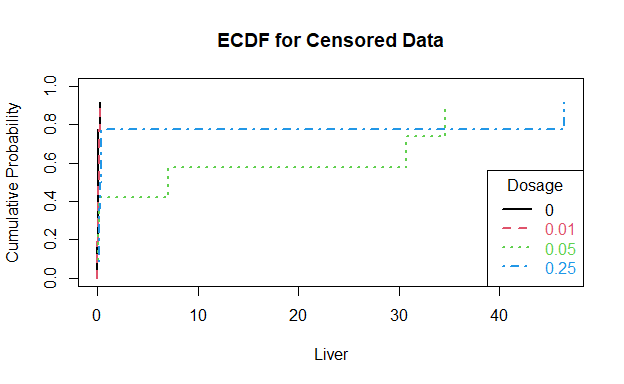

```r
with(Golden,cen_ecdf(Liver,LiverCen,Dosage))
```

This is more easily seen by plotting the empirical cdfs in log units:

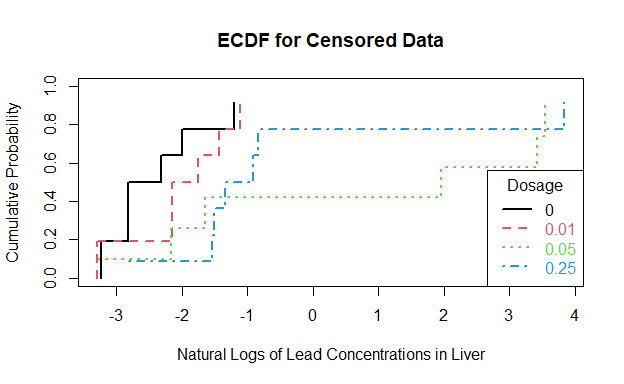

```r
Golden$lnLiver=log(Golden$Liver)

with(Golden,cen_ecdf(lnLiver,LiverCen,Dosage,
                     xlim = c(min(lnLiver), max(lnLiver)),
                     Ylab = "Natural Logs of Lead Concentrations in Liver"))
```

The 0.05 and 0.025 groups appear to have the higher liver lead concentrations (are further to the right) than the other two groups.

### The MLE “ANOVA”

For the parametric approach, use the `cenanova(...)` command to run a censored regression with the groups as ‘factor’ explanatory variables. By default, `cenanova` assumes the residuals follow a lognormal distribution, so use the associated Q-Q plot to see if the residuals in log units appear approximately like a normal distribution.

```r
with(Golden,cenanova(Liver,LiverCen,Dosage))
```

```
#>
#>       MLE test of mean natural logs of CensData: Liver by Factor: Dosage
#>       Assuming lognormal distribution of CensData
#>       Chisq = 10.67  on 3 degrees of freedom     p = 0.0137
#>
```

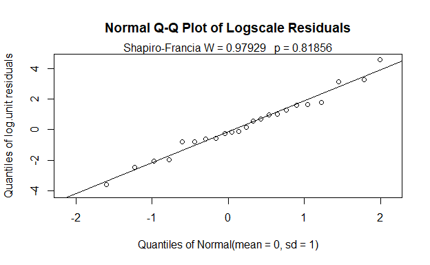

```
#>       mean(0)   mean(0.01)   mean(0.05)   mean(0.25)
#>     -2.989004    -2.701335    0.3031636   -0.7304445
#>
#>   Simultaneous Tests for General Linear Hypotheses
#>
#> Multiple Comparisons of Means: Tukey Contrasts
#>
#>
#> Fit: survreg(formula = logCensData ~ Factor, dist = "gaussian")
#>
#> Linear Hypotheses:
#>                  Estimate Std. Error z value Pr(>|z|)
#> 0.01 - 0 == 0      0.2877     1.0841   0.265   0.9935
#> 0.05 - 0 == 0      3.2922     1.1036   2.983   0.0154 *
#> 0.25 - 0 == 0      2.2586     1.0625   2.126   0.1448
#> 0.05 - 0.01 == 0   3.0045     1.1010   2.729   0.0324 *
#> 0.25 - 0.01 == 0   1.9709     1.0599   1.860   0.2456
#> 0.25 - 0.05 == 0  -1.0336     1.0749  -0.962   0.7712
#> ---
#> Signif. codes:  0 '***' 0.001 '**' 0.01 '*' 0.05 '.' 0.1 ' ' 1
#> (Adjusted p values reported -- single-step method)
```

The overall test has a p-value of 0.014. Therefore the four group mean logarithms (geometric means) differ. p-values for the individual pairwise tests of differences show differences in two pairs of groups. The p-values of 0.0150 (0.05 versus 0 groups) and 0.0323 (0.05 versus 0.01 groups) show that the 0.05 group differs from the lowest two groups, but not from the 0.25 group. The residuals plot shows that log are a very good set of units to use, as their residuals are close to a normal distribution:

If instead you had wanted to test differences in the arithmetic means, use a permutation test as a normal distribution will not fit these data very well.

```r
with(Golden,cenpermanova(Liver,LiverCen,Dosage))
```

```
#>  Permutation test of mean CensData: Liver   by Factor: Dosage
#>      9999 Permutations
#> Test Statistic = 1211 to 1211       p = 0.1432 to 0.145
#>
#>    mean(0)   mean(0.01)   mean(0.05)   mean(0.25)
#>     0.1000       0.1395      12.1100       6.8660
```

No significant difference in the means was found. This test did not assume a normal distribution, though it is still influenced by outliers because it evaluates means, which are influenced by outliers. The permutation test will not extrapolate data to values below zero as would MLE.

Note that the means of two groups, and so much of the data in the two groups, falls below zero when estimated by MLE assuming a normal distribution:

```r
with(Golden,cenanova(Liver,LiverCen,Dosage,LOG=FALSE))
```

```
#>
#>       MLE test of mean CensData: Liver   by Factor: Dosage
#>       Assuming normal distribution of CensData
#>       Chisq = 6.889  on 3 degrees of freedom     p = 0.0755
#>
#>    NOTE: Data with nondetects may be projected below 0 with MLE normal distribution.
#>    If so, p-values will be unreliable (often too small).  Use perm test instead.
#>
```

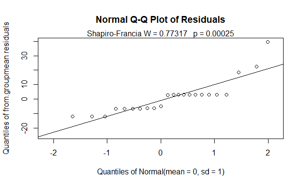

```
#>       mean(0)   mean(0.01)   mean(0.05)   mean(0.25)
#>     -2.889326    -2.847255     12.11417     6.865988
#>
#>   Simultaneous Tests for General Linear Hypotheses
#>
#> Multiple Comparisons of Means: Tukey Contrasts
#>
#>
#> Fit: survreg(formula = CensData ~ Factor, dist = "gaussian")
#>
#> Linear Hypotheses:
#>                  Estimate Std. Error z value Pr(>|z|)
#> 0.01 - 0 == 0     0.04207    6.65879   0.006    1.000
#> 0.05 - 0 == 0    15.00349    6.71721   2.234    0.114
#> 0.25 - 0 == 0     9.75531    6.47075   1.508    0.433
#> 0.05 - 0.01 == 0 14.96142    6.71674   2.227    0.116
#> 0.25 - 0.01 == 0  9.71324    6.47026   1.501    0.437
#> 0.25 - 0.05 == 0 -5.24818    6.50033  -0.807    0.851
#> (Adjusted p values reported -- single-step method)
```

The p-value of 0.0755 is too small because the group differences are exaggerated by pushing data down below 0. Given that the actual data cannot go below zero, the cenpermanova p-value of 0.14 is a much more realistic test result.

## Correlation and Regression

```r
data(Recon)
```

First test for high vifs by computing a standard regression equation that ignores the censoring indicator column, ignoring all results except for the vifs:

```r
vif(lm(AtraConc ~ Area + Applic + PctCorn + SoilGp + Temp + Precip + Dyplant + Pctl,Recon))
```

```
#>     Area   Applic  PctCorn   SoilGp     Temp   Precip  Dyplant     Pctl
#> 1.101992 2.739602 1.996707 1.480307 2.587299 2.206457 1.068839 1.131753
```

All of the variables appear uncorrelated with the others (all VIFs well below 10). Therefore the p-values obtained in regression should be reliable.

**Step 1** - Create the 8-X variable `data.frame` and run the regression with all variables. Decide which scale the Y variable should be used (no transformation, log, cube-root).

```r
recon.8 <- with(Recon,data.frame(Area, Applic, PctCorn, SoilGp, Temp, Precip, Dyplant, Pctl))
reg.recon.8 <- with(Recon,cencorreg(AtraConc, AtraCen, recon.8))
```

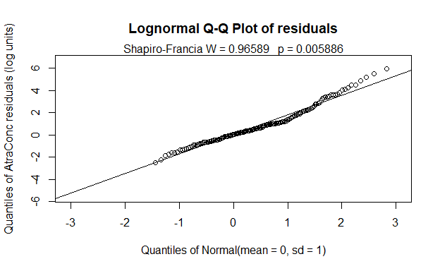

```
#>  Likelihood R2 = 0.6387                     AIC = 804.4707
#>  Rescaled Likelihood R2 = 0.6771            BIC = 843.968
#>  McFaddens R2 = 0.3547157
#>

summary(reg.recon.8)
#>
#> Call:
#> survreg(formula = "log(AtraConc)", data = "Area+Applic+PctCorn+SoilGp+Temp+Precip+Dyplant+Pctl",
#>     dist = "gaussian")
#>                 Value Std. Error      z       p
#> (Intercept) -8.76e+00   1.25e+00  -7.00 2.6e-12
#> Area         2.19e-05   1.98e-05   1.11  0.2685
#> Applic      -2.75e-02   1.73e-02  -1.59  0.1127
#> PctCorn      5.91e-02   1.88e-02   3.14  0.0017
#> SoilGp       2.35e-01   3.66e-01   0.64  0.5198
#> Temp         6.25e-01   1.15e-01   5.44 5.3e-08
#> Precip      -5.18e-03   1.39e-02  -0.37  0.7087
#> Dyplant     -1.86e-02   1.51e-03 -12.36 < 2e-16
#> Pctl         4.17e-02   4.45e-03   9.36 < 2e-16
#> Log(scale)   5.96e-01   6.12e-02   9.75 < 2e-16
#>
#> Scale= 1.82
#>
#> Gaussian distribution
#> Loglik(model)= -391.7   Loglik(intercept only)= -607.1
#>  Chisq= 430.68 on 8 degrees of freedom, p= 5.1e-88
#> Number of Newton-Raphson Iterations: 6
#> n= 423
```

**Step 2** - Decide whether to transform the scale of each X variable. Run the partplots procedure to see whether curvature in the Y-X relationship means that a transformation of the X variable should be taken.

```
#> Area
#>  untransformed
#>  Likelihood R2 = 0.6387                     AIC = 804.4707
#> cube root
#>  Likelihood R2 = 0.6388                     AIC = 804.4493
#> log transform
#>  Likelihood R2 = 0.6389                     AIC = 804.3342
#> Decrease in AIC from transformation of Area = 0.1364942
#>
#> Applic
#>  untransformed
#>  Likelihood R2 = 0.6387                     AIC = 804.4707
#> cube root
#>  Likelihood R2 = 0.6378                     AIC = 805.5327
#> log transform
#>  Likelihood R2 = 0.6371                     AIC = 806.3659
#> Decrease in AIC from transformation of Applic = 0
#>
#> PctCorn
#>  untransformed
#>  Likelihood R2 = 0.6387                     AIC = 804.4707
#> cube root
#>  Likelihood R2 = 0.641                     AIC = 801.7987
#> log transform
#>  Likelihood R2 = 0.6423                     AIC = 800.281
#> Decrease in AIC from transformation of PctCorn = 4.189691
#>
#> SoilGp
#>  untransformed
#>  Likelihood R2 = 0.6387                     AIC = 804.4707
#> cube root
#>  Likelihood R2 = 0.6385                     AIC = 804.6955
#> log transform
#>  Likelihood R2 = 0.6385                     AIC = 804.7786
#> Decrease in AIC from transformation of SoilGp = 0
#>
#> Temp
#>  untransformed
#>  Likelihood R2 = 0.6387                     AIC = 804.4707
#> cube root
```

[output cut: 8 more lines]

```
#> cube root
#>  Likelihood R2 = 0.6387                     AIC = 804.4702
#> log transform
#>  Likelihood R2 = 0.6387                     AIC = 804.4687
#> Decrease in AIC from transformation of Precip = 0.002027404
#>
#> Dyplant
#>  untransformed
#>  Likelihood R2 = 0.6387                     AIC = 804.4707
#> cube root
#>  Likelihood R2 = 0.6374                     AIC = 806.063
#> log transform
#> Cannot take logs of zero or negative values.
#> Decrease in AIC from transformation of Dyplant = 0
#>
```

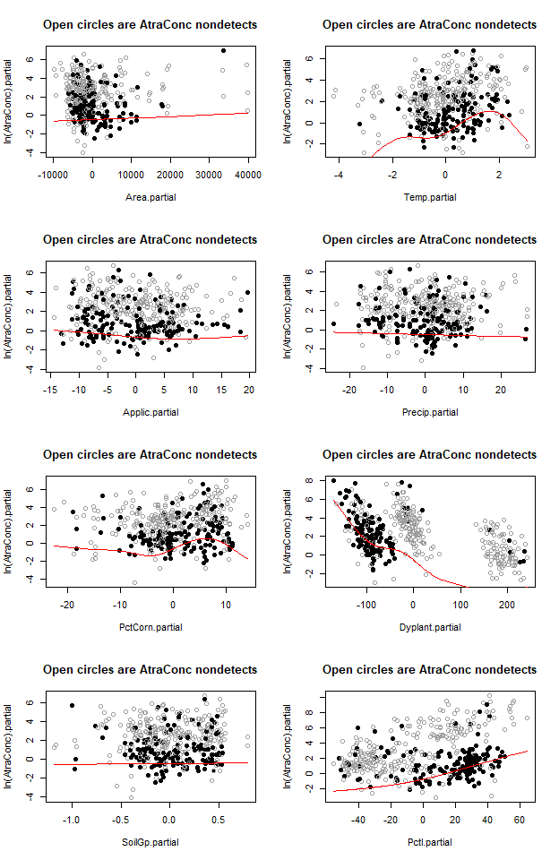

```
#> Pctl
#>  untransformed
#>  Likelihood R2 = 0.6387                     AIC = 804.4707
#> cube root
#>  Likelihood R2 = 0.6267                     AIC = 818.3161
#> log transform
#> Cannot take logs of zero or negative values.
#> Decrease in AIC from transformation of Pctl = 0
#>
```

```r
layout(matrix(1:8,4,2))
with(Recon,partplots(AtraConc, AtraCen, recon.8,multiplot = F))
```

Only PctCorn showed an appreciable drop in AIC with a transformation. As a percentage it is bounded by 0 and 100 so it’s a little odd to do a transform. However the partial plot shows an increase in the percent of “filled circle” detected observations and so a general increase in atrazine with increasing PctCorn. The relationship may be nonlinear so I’ll take the cube root of PctCorn.

```r
Recon$cbrtPctCorn <- recon.8$PctCorn^(1/3)

recon.8onecube <- cbind(recon.8[, -3], Recon$cbrtPctCorn)

reg.recon.8onecube = with(Recon,cencorreg(AtraConc, AtraCen, recon.8onecube))
```

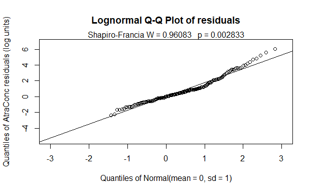

```
#>  Likelihood R2 = 0.641                     AIC = 801.7987
#>  Rescaled Likelihood R2 = 0.6795            BIC = 841.296
#>  McFaddens R2 = 0.3569165
#>
```

```
#> Area
#>  untransformed
#>  Likelihood R2 = 0.641                     AIC = 801.7987
#> cube root
#>  Likelihood R2 = 0.641                     AIC = 801.8123
#> log transform
#>  Likelihood R2 = 0.6411                     AIC = 801.6904
#> Decrease in AIC from transformation of Area = 0.1083058
#>
#> Applic
#>  untransformed
#>  Likelihood R2 = 0.641                     AIC = 801.7987
#> cube root
#>  Likelihood R2 = 0.6404                     AIC = 802.5295
#> log transform
#>  Likelihood R2 = 0.6397                     AIC = 803.316
#> Decrease in AIC from transformation of Applic = 0
#>
#> SoilGp
#>  untransformed
#>  Likelihood R2 = 0.641                     AIC = 801.7987
#> cube root
#>  Likelihood R2 = 0.6408                     AIC = 802.0643
#> log transform
#>  Likelihood R2 = 0.6407                     AIC = 802.1689
#> Decrease in AIC from transformation of SoilGp = 0
#>
#> Temp
#>  untransformed
#>  Likelihood R2 = 0.641                     AIC = 801.7987
#> cube root
#>  Likelihood R2 = 0.6404                     AIC = 802.5673
#> log transform
#>  Likelihood R2 = 0.6399                     AIC = 803.0917
#> Decrease in AIC from transformation of Temp = 0
#>
#> Precip
#>  untransformed
#>  Likelihood R2 = 0.641                     AIC = 801.7987
#> cube root
```

[output cut: 8 more lines]

```
#> cube root
#>  Likelihood R2 = 0.6391                     AIC = 804.098
#> log transform
#> Cannot take logs of zero or negative values.
#> Decrease in AIC from transformation of Dyplant = 0
#>
#> Pctl
#>  untransformed
#>  Likelihood R2 = 0.641                     AIC = 801.7987
#> cube root
#>  Likelihood R2 = 0.6287                     AIC = 816.0618
#> log transform
#> Cannot take logs of zero or negative values.
#> Decrease in AIC from transformation of Pctl = 0
#>
```

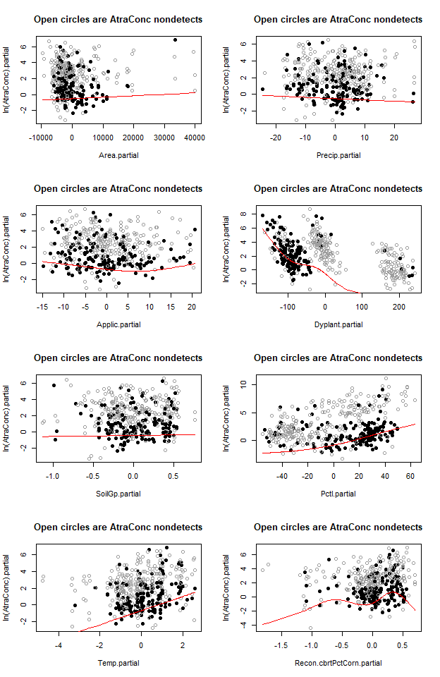

```
#> Recon.cbrtPctCorn
#>  untransformed
#>  Likelihood R2 = 0.641                     AIC = 801.7987
#> cube root
#>  Likelihood R2 = 0.6419                     AIC = 800.788
#> log transform
#>  Likelihood R2 = 0.6423                     AIC = 800.281
#> Decrease in AIC from transformation of Recon.cbrtPctCorn = 1.517664
#>
```

```r
layout(matrix(1:8,4,2))
with(Recon,partplots(AtraConc, AtraCen, recon.8onecube,multiplot = F))
```

No other variables indicate a further transformation is necessary after running partplots – the cbrtPctCorn variable is already transformed so taking the log or cube root of the cube root would not make much sense.

**Step 3a** - Can we lower the AIC by dropping unimportant variables?

```r
summary(reg.recon.8onecube)
```

```
#>
#> Call:
#> survreg(formula = "log(AtraConc)", data = "Area+Applic+SoilGp+Temp+Precip+Dyplant+Pctl+Recon.cbrtPctCorn",
#>     dist = "gaussian")
#>                       Value Std. Error      z       p
#> (Intercept)       -1.07e+01   1.58e+00  -6.74 1.6e-11
#> Area               2.04e-05   1.97e-05   1.03 0.30074
#> Applic            -2.61e-02   1.62e-02  -1.61 0.10795
#> SoilGp             2.69e-01   3.62e-01   0.74 0.45644
#> Temp               6.41e-01   1.15e-01   5.57 2.6e-08
#> Precip            -9.65e-03   1.41e-02  -0.68 0.49348
#> Dyplant           -1.86e-02   1.50e-03 -12.44 < 2e-16
#> Pctl               4.16e-02   4.42e-03   9.40 < 2e-16
#> Recon.cbrtPctCorn  1.23e+00   3.50e-01   3.51 0.00046
#> Log(scale)         5.89e-01   6.12e-02   9.64 < 2e-16
#>
#> Scale= 1.8
#>
#> Gaussian distribution
#> Loglik(model)= -390.4   Loglik(intercept only)= -607.1
#>  Chisq= 433.35 on 8 degrees of freedom, p= 1.4e-88
#> Number of Newton-Raphson Iterations: 6
#> n= 423
```

Both Precip and Soil Gp are very non-significant. Soil Group was a number looked up in a book at the county scale and so wasn’t really expected to provide much information (your insight as a scientist is needed when using regression). Delete either Precip or Soil Group and run the 7-variable model.

```r
# an alternative way to make a data.frame without using data.frame(...)
recon.7 <- Recon[,c("Area", "Applic", "cbrtPctCorn", "Temp", "Precip", "Dyplant", "Pctl")]

reg.recon.7 <- with(Recon,cencorreg(AtraConc, AtraCen, recon.7))
```

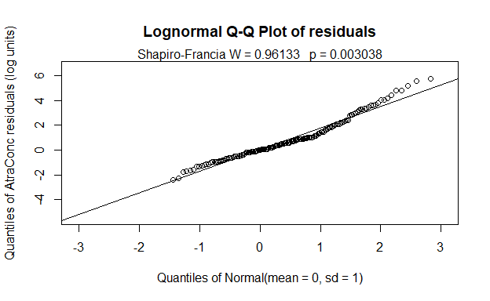

```
#>  Likelihood R2 = 0.6405                     AIC = 800.3545
#>  Rescaled Likelihood R2 = 0.679            BIC = 835.8021
#>  McFaddens R2 = 0.3564587
#>
```

AIC has decreased so this is better than the 8-variable model. The residuals plot looks much the same – this is expected in regression. The normality of residuals is primarily determined by the scale of the Y variable. Going to a six-variable model is an easy choice: Precip has a high p-value.

```r
recon.6 <- Recon[,c("Area", "Applic", "cbrtPctCorn", "Temp","Dyplant", "Pctl")]

reg.recon.6 <- with(Recon,cencorreg(AtraConc, AtraCen, recon.6))
```

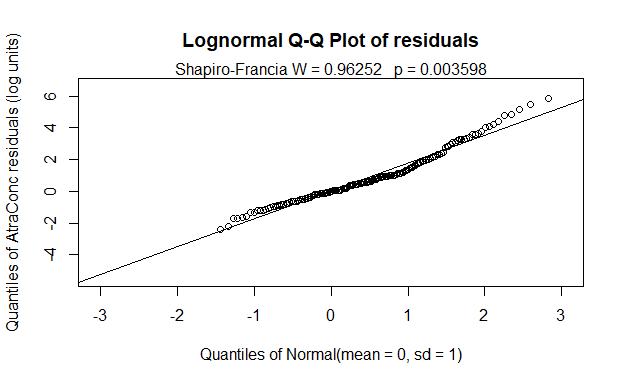

```
#>  Likelihood R2 = 0.6404                     AIC = 798.5004
#>  Rescaled Likelihood R2 = 0.6789            BIC = 829.8982
#>  McFaddens R2 = 0.3563385
#>

summary(reg.recon.6)
#>
#> Call:
#> survreg(formula = "log(AtraConc)", data = "Area+Applic+cbrtPctCorn+Temp+Dyplant+Pctl",
#>     dist = "gaussian")
#>                 Value Std. Error      z       p
#> (Intercept) -1.02e+01   1.35e+00  -7.55 4.3e-14
#> Area         2.27e-05   1.95e-05   1.16 0.24482
#> Applic      -2.35e-02   1.59e-02  -1.48 0.13925
#> cbrtPctCorn  1.11e+00   3.19e-01   3.48 0.00051
#> Temp         6.06e-01   9.03e-02   6.71 2.0e-11
#> Dyplant     -1.86e-02   1.49e-03 -12.45 < 2e-16
#> Pctl         4.17e-02   4.41e-03   9.45 < 2e-16
#> Log(scale)   5.90e-01   6.12e-02   9.65 < 2e-16
#>
#> Scale= 1.8
#>
#> Gaussian distribution
#> Loglik(model)= -390.8   Loglik(intercept only)= -607.1
#>  Chisq= 432.65 on 6 degrees of freedom, p= 2.7e-90
#> Number of Newton-Raphson Iterations: 6
#> n= 423
```

```r
recon.5 <- Recon[,c("Applic", "cbrtPctCorn", "Temp","Dyplant", "Pctl")]

reg.recon.5 <- with(Recon,cencorreg(AtraConc, AtraCen, recon.5))
```

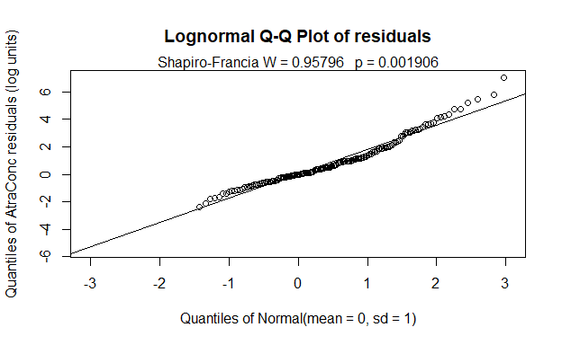

```
#>  Likelihood R2 = 0.6393                     AIC = 797.8078
#>  Rescaled Likelihood R2 = 0.6777            BIC = 825.1559
#>  McFaddens R2 = 0.3552617
#>

summary(reg.recon.5)
#>
#> Call:
#> survreg(formula = "log(AtraConc)", data = "Applic+cbrtPctCorn+Temp+Dyplant+Pctl",
#>     dist = "gaussian")
#>                Value Std. Error      z       p
#> (Intercept) -9.85413    1.31831  -7.47 7.7e-14
#> Applic      -0.02454    0.01594  -1.54 0.12368
#> cbrtPctCorn  1.10879    0.32018   3.46 0.00053
#> Temp         0.58724    0.08900   6.60 4.2e-11
#> Dyplant     -0.01862    0.00150 -12.45 < 2e-16
#> Pctl         0.04155    0.00442   9.40 < 2e-16
#> Log(scale)   0.59339    0.06116   9.70 < 2e-16
#>
#> Scale= 1.81
#>
#> Gaussian distribution
#> Loglik(model)= -391.4   Loglik(intercept only)= -607.1
#>  Chisq= 431.34 on 5 degrees of freedom, p= 5.2e-91
#> Number of Newton-Raphson Iterations: 6
#> n= 423
```

AIC has decreased by 0.7, so this is a very slightly better model. The only other insignificant variable is Applic, the application amounts of ag chemicals. These are known only on a county level so are estimated by cutting and pasting county boundaries with watershed boundaries. They also are voluntary amounts, and may not always provide accurate information to the Federal government. But probably the main evidence against the variable is its negative slope – we would expect more atrazine to wash off with more applications. So we drop this variable to see its effect.

```r
recon.4 <- Recon[,c( "cbrtPctCorn", "Temp","Dyplant", "Pctl")]

reg.recon.4 <- with(Recon,cencorreg(AtraConc, AtraCen, recon.4))
```

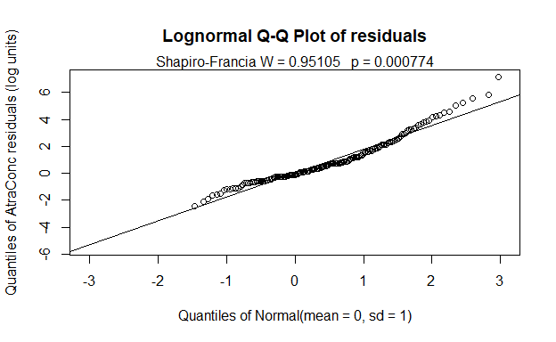

```
#>  Likelihood R2 = 0.6373                     AIC = 798.192
#>  Rescaled Likelihood R2 = 0.6756            BIC = 821.4904
#>  McFaddens R2 = 0.3532981
#>

summary(reg.recon.4)
#>
#> Call:
#> survreg(formula = "log(AtraConc)", data = "cbrtPctCorn+Temp+Dyplant+Pctl",
#>     dist = "gaussian")
#>                Value Std. Error      z       p
#> (Intercept) -8.79657    1.10700  -7.95 1.9e-15
#> cbrtPctCorn  0.81989    0.25697   3.19  0.0014
#> Temp         0.51042    0.07332   6.96 3.4e-12
#> Dyplant     -0.01869    0.00150 -12.47 < 2e-16
#> Pctl         0.04050    0.00437   9.26 < 2e-16
#> Log(scale)   0.59752    0.06121   9.76 < 2e-16
#>
#> Scale= 1.82
#>
#> Gaussian distribution
#> Loglik(model)= -392.6   Loglik(intercept only)= -607.1
#>  Chisq= 428.96 on 4 degrees of freedom, p= 1.5e-91
#> Number of Newton-Raphson Iterations: 6
#> n= 423
```

The AIC goes up but only a little. This would be the scientist’s choice to use either the 5-variable or the 4-variable model. I usually choose the larger model if all p-values are under 0.10 because AIC and similar metrics are known to choose too few variables. Here however the Applic p-value in the 5-varable model is 0.124 and so I’d drop it, choosing the 4-variable model. What is also behind my decision to drop Applic is that it is a crude measure of amount of pesticide applied (county level data cut and pasted) and cbrtPctCorn essentially measures the same thing. Use your knowledge of the data to make your decision.

**Step 3b** - Use the bestaic function to lower the AIC?

Starting with the full 8 variables, though PctCorn has been transformed to become cbrtPctCorn, run the bestaic function to see what models the computer selects:

```r
with(Recon,bestaic(AtraConc, AtraCen, recon.8onecube))
```

```
#> Evaluating 255 models and printing the 10 lowest AIC models
#>  n.xvars                                            model.xvars      aic
#>    5                 Applic Temp Dyplant Pctl Recon.cbrtPctCorn 797.8078
#>    4                        Temp Dyplant Pctl Recon.cbrtPctCorn 798.1920
#>    6            Area Applic Temp Dyplant Pctl Recon.cbrtPctCorn 798.5004
#>    5                   Area Temp Dyplant Pctl Recon.cbrtPctCorn 798.6990
#>    6          Applic SoilGp Temp Dyplant Pctl Recon.cbrtPctCorn 799.4286
#>    6          Applic Temp Precip Dyplant Pctl Recon.cbrtPctCorn 799.6515
#>    5                 SoilGp Temp Dyplant Pctl Recon.cbrtPctCorn 800.0487
#>    5                 Temp Precip Dyplant Pctl Recon.cbrtPctCorn 800.0798
#>    7     Area Applic SoilGp Temp Dyplant Pctl Recon.cbrtPctCorn 800.2693
#>    7     Area Applic Temp Precip Dyplant Pctl Recon.cbrtPctCorn 800.3545
```

Many models are very similar in AIC, but the ‘best’ is the 5-variable model that we named `recon.5`, above. Second best was the four variable model we called `recon.4.` So by deleting sequentially we did get to the “best” models, but this is a lot quicker. As you see in the list there are several other models around an AIC of 798, and if it were less expensive to use the variables in one of these, it would be an excellent substitute for the mathematically lowest AIC model. For example the fourth model down uses Area instead of Applic, with all other variables the same. If `Applic` were expensive to collect, this model has an AIC only 0.9 units higher.

**Finding the best one-variable model.** To find the best 1-variable model (just to compare to the ATS equation), run the four possible 1-variable models using the variables from the 4-variable model.

```r
reg.recon.cbrtPctCorn  <- with(Recon,cencorreg(AtraConc, AtraCen, cbrtPctCorn))
```

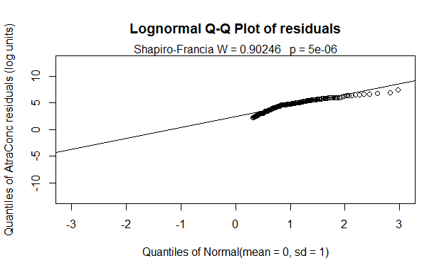

```
#>  Likelihood R = 0.1282                     AIC = 1214.138
#> Rescaled Likelihood R = 0.132            BIC = 1225.288
#>  McFaddens R = 0.07598
#>
```

```r
reg.recon.Temp   <- with(Recon,cencorreg(AtraConc, AtraCen, Temp))
```

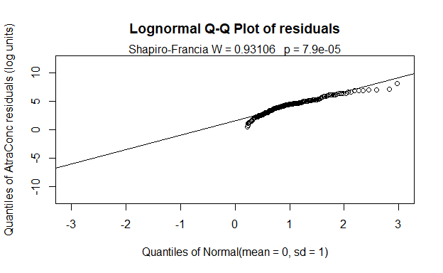

```
#>  Likelihood R = 0.2952                     AIC = 1182.583
#> Rescaled Likelihood R = 0.3039            BIC = 1193.733
#>  McFaddens R = 0.1782
#>
```

```r
reg.recon.Dyplant   <- with(Recon,cencorreg(AtraConc, AtraCen, Dyplant ))
```

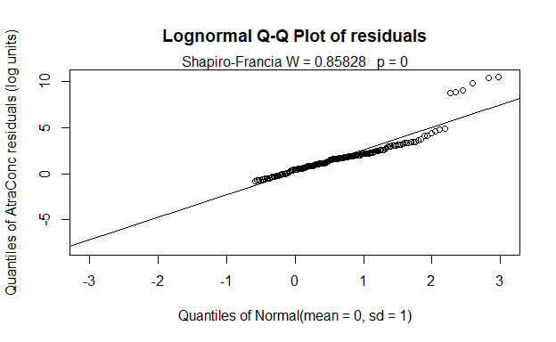

```
#>  Likelihood R = -0.6899                     AIC = 947.8357
#> Rescaled Likelihood R = -0.7103            BIC = 958.9849
#>  McFaddens R = -0.4745
#>
```

```r
reg.recon.Pctl  <- with(Recon,cencorreg(AtraConc, AtraCen, Pctl))
```

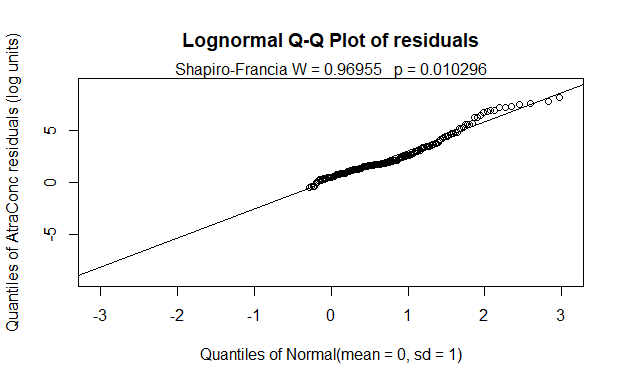

```
#>  Likelihood R = 0.5878                     AIC = 1041.861
#> Rescaled Likelihood R = 0.6052            BIC = 1053.011
#>  McFaddens R = 0.3843
#>
```

The Dyplant (days since planting) variable has the lowest AIC. Its residuals plot (above) shows a linear pattern pulled away from the normal theory line because of six high outliers. The negative slope is reasonable: as there are more days since planting of corn, and atrazine is only applied before planting, the more time it sits on the ground the lower the amounts available to be washed off into the stream. The outliers are probably high flows that would be accounted for by the Pctl variable if it were in the model. Here are the details for the Dyplant 1-variable model:

```r
summary(reg.recon.Dyplant)
```

```
#>
#> Call:
#> survreg(formula = "log(AtraConc)", data = "Dyplant", dist = "gaussian")
#>                Value Std. Error      z       p
#> (Intercept)  1.34758    0.22401   6.02 1.8e-09
#> Dyplant     -0.03063    0.00229 -13.40 < 2e-16
#> Log(scale)   0.96971    0.06270  15.47 < 2e-16
#>
#> Scale= 2.64
#>
#> Gaussian distribution
#> Loglik(model)= -470.4   Loglik(intercept only)= -607.1
#>  Chisq= 273.31 on 1 degrees of freedom, p= 2.2e-61
#> Number of Newton-Raphson Iterations: 6
#> n= 423
```

**The Nonparametric ATS line:** Using Dyplant as the X variable,

```r
with(Recon,ATS(AtraConc, AtraCen, Dyplant))
```

```
#> Akritas-Theil-Sen line for censored data
#>
#> ln(AtraConc) = 3.3637 -0.0364 * Dyplant
#> Kendall's tau = -0.3995   p-value = 0
#>
```

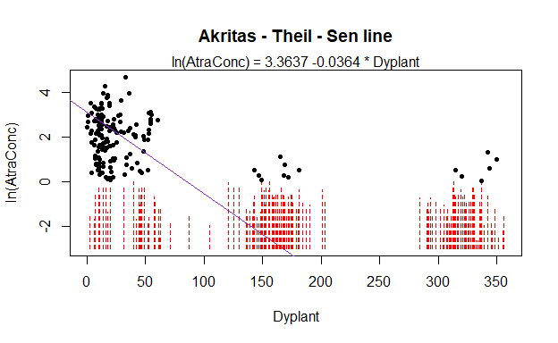

Seeing this transformed back into the original units will look much better.

```r
with(Recon,ATS(AtraConc, AtraCen, Dyplant,retrans=TRUE))
```

```
#> Akritas-Theil-Sen line for censored data
#>
#> ln(AtraConc) = 3.3637 -0.0364 * Dyplant
#> Kendall's tau = -0.3995   p-value = 0
#>
```

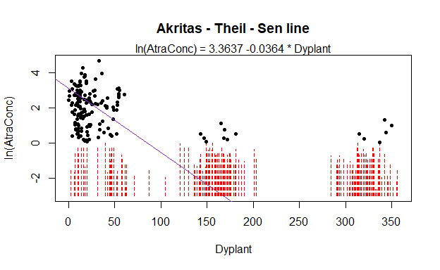

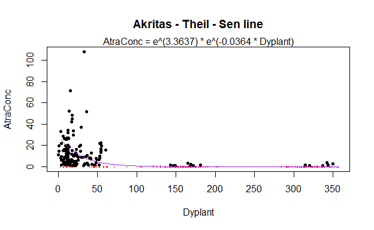

For this dataset, the maximum likelihood and ATS slopes for Dyplant are very similar (different by 0.006). The intercepts are similar as well when you realize that a difference of 2.0 is small when concentrations go up to 100.

The plot of the relationship of atrazine to flow percentile (Pctl) shows a clear washoff effect at higher flows:

```r
with(Recon,ATS(AtraConc,AtraCen, Pctl,retrans=TRUE))
```

```
#> Akritas-Theil-Sen line for censored data
#>
#> ln(AtraConc) = -5.4878 + 0.0889 * Pctl
#> Kendall's tau = 0.3465   p-value = 0
#>
```

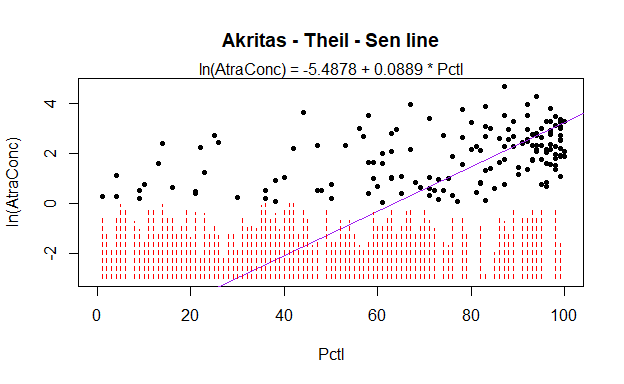

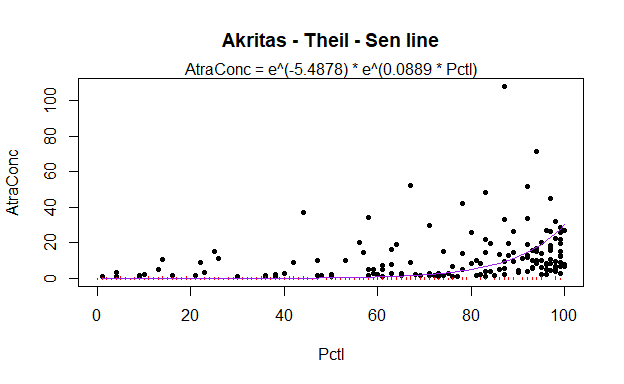

There is not yet (June 2022) a good nonparametric “multiple regression” method for censored data. There are ‘robust regression’ methods that perform nonparametric regression but I’ve never seen them applied to censored data.

## Trend Analysis for Censored Data

Load the Gales_Creek dataset:

```r
data(Gales_Creek)
```

### Nonparametric Methods

*ATS (no covariate or seasonal variation)* We choose to use the original units (`LOG=FALSE`) because the data appear linear over time with one large outlier, and a nonparametric test will not be overly influenced by one outlier. Running the ATS function on concentration versus decimal time, we find strong evidence for a downtrend (p = 0.006):

```r
with(Gales_Creek,ATS(TCr,CrND,dectime,LOG=FALSE))
```

```
#> Akritas-Theil-Sen line for censored data
#>
#> TCr = 181.2617 -0.0896 * dectime
#> Kendall's tau = -0.234   p-value = 0.00648
#>
```

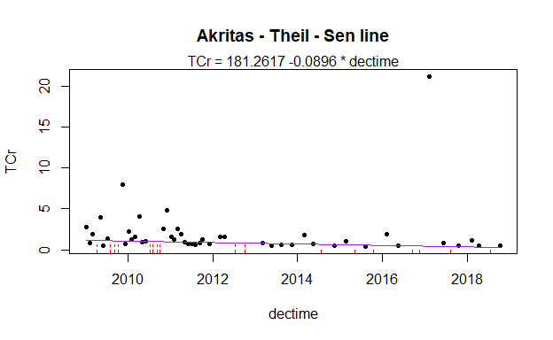

It isn’t easy to see on the plot, but the detection limits shown as dashed lines are higher before 2012 as opposed to after 2012. The methods of this section of the course work well with multiple detection limits in the data record.

*ATS on residuals from a smooth with a covariate* Using the centrend function, we first smooth the chromium – streamflow relationship, and then test the residuals for trend:

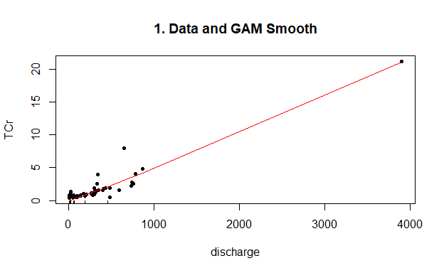

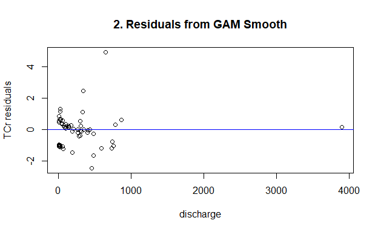

```
#> Trend analysis of TCr adjusted for discharge
#> Akritas-Theil-Sen line for censored data
#>
#> TCr residuals = 60.117 -0.0301 * dectime
#> Kendall's tau = -0.0579   p-value = 0.5051
#>
```

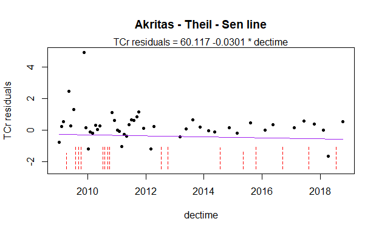

```r
with(Gales_Creek,centrend(TCr,CrND,discharge,dectime))
```

There is no trend in chromium concentration once the effect of streamflow has been subtracted out. It appears that the evidence for a downtrend was due to a change in the flow regime over the time period. There is a strong relationship between flow and chromium concentrations.

*Seasonal Kendall test* Perhaps there is a trend in either the dry season alone, ignoring the effects of high flows on the trend test? Perform the Seasonal Kendall test using the censeaken function and pay attention to the individual season results by plotting them using the `seaplots = TRUE` option.

```
#>
#>  DATA ANALYZED: TCr vs dectime by Season
#> ----------
```

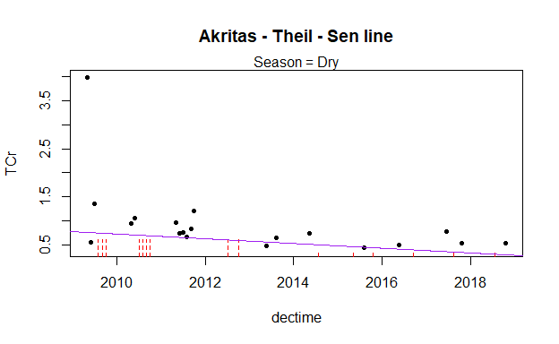

```
#>   Season  N    S    tau     pval Intercept    slope
#> 1    Dry 34 -120 -0.214 0.069046    101.24 -0.05001
#> ----------
```

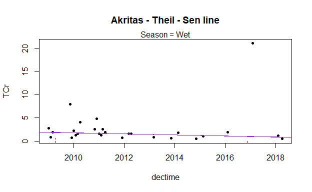

```
#>   Season  N   S    tau    pval Intercept   slope
#> 1    Wet 29 -83 -0.204 0.12381    233.15 -0.1151
#> ----------
#> Seasonal Kendall test and Theil-Sen line
```

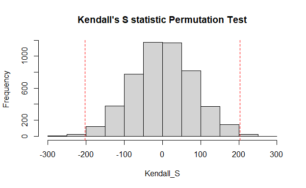

```
#>   reps_R  N S_SK tau_SK pval intercept    slope
#> 1   4999 63 -203  -0.21 0.01    181.26 -0.08965
#> ----------
```

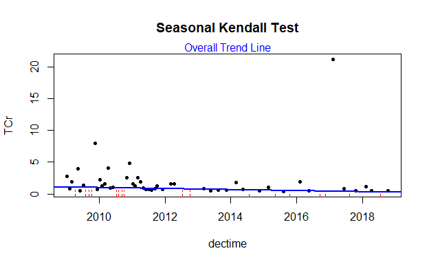

```r
with(Gales_Creek,censeaken(dectime,TCr,CrND,Season,seaplots=TRUE))
```

There is an overall trend once the Seasonal Kendall test has removed all comparisons between values in different seasons. Also, the dry season has a p-value of 0.069. The prevailing wisdom in statistics in 2019 is to not get too rigid about an alpha of 0.05. A value of 0.069 is close to 0.05 and the trend in the dry season graph appears strong. I would report in this case that there is an overall downtrend and a downtrend in the dry season. The high flows in the wet season were preventing the non-seasonal `centrend` function from seeing the trend.

*Seasonal Kendall test with a covariate* The centrendsea function will perform the seasonal Kendall test on the residuals from a GAM smooth of the original Y variable verses a covariate, like flow. This first computes the same covariate adjustment of the centrend function and using the residuals from the smooth, tests the “covariate-adjusted trend” using the Seasonal Kendall test. The variables to be entered are, in order, the Y variable to be tested for trend, the T/F indicator of censoring for the Y variable, the covariate, the time variable, and the season category variable.

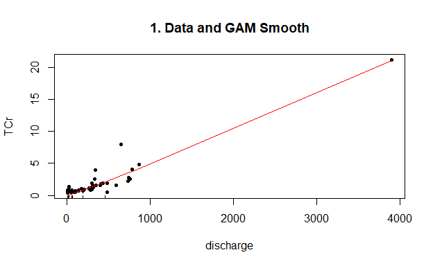

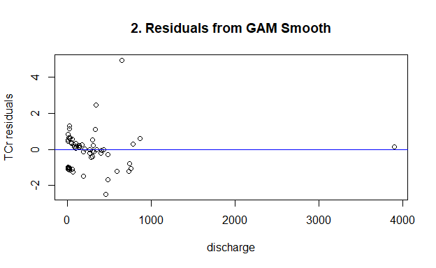

```
#>
#>  Trend analysis by Season of: TCr adjusted for discharge
#> ----------
```

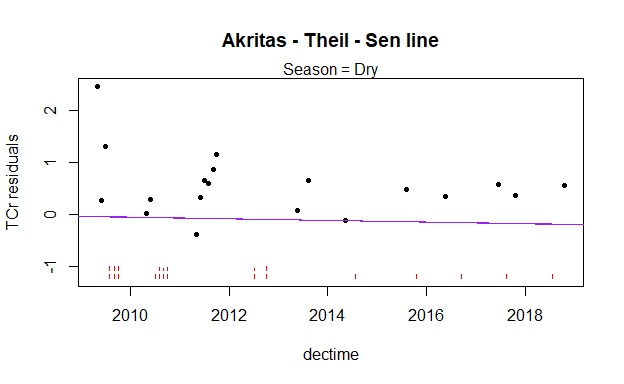

```
#>   Season  N  S     tau    pval Intercept   slope
#> 1    Dry 34 -8 -0.0143 0.91638     34.52 -0.0172
#> ----------
```

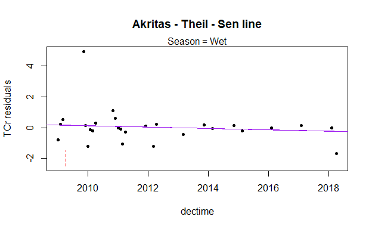

```
#>   Season  N   S    tau    pval Intercept    slope
#> 1    Wet 29 -58 -0.143 0.28481    86.864 -0.04316
#> ----------
#> Seasonal Kendall test and Akritas-Theil-Sen line on residuals
```

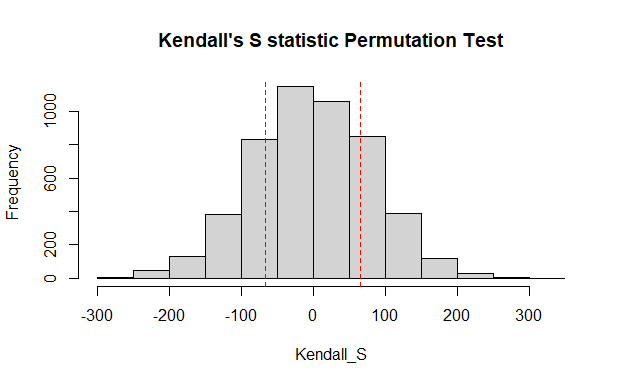

```
#>   reps_R  N S_SK  tau_SK   pval intercept    slope
#> 1   4999 63  -66 -0.0683 0.4366    59.654 -0.02967
#> ----------
```

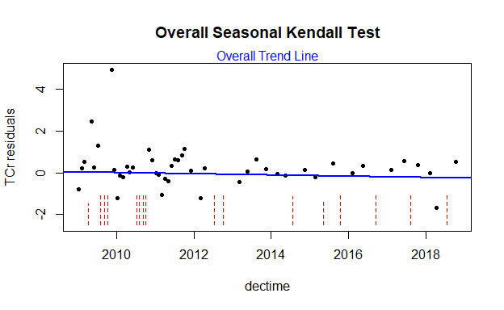

```r
with(Gales_Creek,centrendsea(TCr,CrND,discharge,dectime,Season))
```

There is no trend in flow-adjusted chromium found for this site and dates. The slight decrease of the ATS line above, which includes the influence of the below detection limit observations as well as detected observations, is not significantly different from a zero slope.

### Parametric Method

*Simple Censored Regression* Using the default log transformation of chromium because we know there is one large outlier lurking, the `cencorreg` function shows that the residuals are not a normal distribution, but the data appear quite straight except for the one high outlier. There is likely no better scale to work in – untransformed concentrations would be far worse. Without deleting the outlier (you should check it to see if there’s been an error, but you can’t because this isn’t your data!), do not delete the outlier without cause and work in the log units.

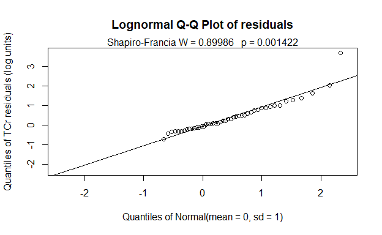

```
#>  Likelihood R = -0.2665                     AIC = 163.4814
#> Rescaled Likelihood R = -0.2775            BIC = 168.9581
#>  McFaddens R = -0.1697
#>
#> Call:
#> survreg(formula = "log(TCr)", data = "dectime", dist = "gaussian")
#>
#> Coefficients:
#>  (Intercept)      dectime
#> 192.32546251  -0.09565766
#>
#> Scale= 0.9595278
#>
#> Loglik(model)= -78.2   Loglik(intercept only)= -80.6
#>  Chisq= 4.64 on 1 degrees of freedom, p= 0.0312
#> n= 63
```

```r
with(Gales_Creek,cencorreg(TCr,CrND,dectime))
```

The regression p-value of 0.03 says that there is a trend. The slope of – 0.095 log units per year will be approximately a 10% decrease in chromium per year. But is this slope a good estimate, given that there appear to be a confounding effect of streamflow? So perform a censored multiple regression.

*Censored Multiple Regression* Create a data frame of the two X variables, dectime and flow, and try again. This is a better model if flow explains a lot of the variation in concentration. If that’s the case the model’s AIC will be lower than the previous AIC of 163.48.

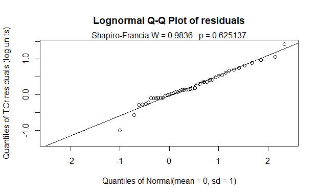

```
#>  Likelihood R2 = 0.5926                     AIC = 113.5493
#>  Rescaled Likelihood R2 = 0.6424            BIC = 121.1848
#>  McFaddens R2 = 0.351119
#>
#> Call:
#> survreg(formula = "log(TCr)", data = "dectime+discharge", dist = "gaussian")
#>
#> Coefficients:
#>   (Intercept)       dectime     discharge
#> 220.206866401  -0.109654346   0.001290593
#>
#> Scale= 0.5499025
#>
#> Loglik(model)= -52.3   Loglik(intercept only)= -80.6
#>  Chisq= 56.57 on 2 degrees of freedom, p= 5.19e-13
#> n= 63
```

```r
timeflow <- with(Gales_Creek,data.frame(dectime, discharge))
with(Gales_Creek,cencorreg(TCr,CrND,timeflow))
```

The QQ plot looks great, and the residuals do not differ from a normal distribution. The AIC is considerably lower for the 2-variable model, so this model that accounts for flow variation should be used instead of the original model.

*Censored Multiple Regression with Seasonal Variables* Sounds like a menu option (‘seasonal vegetables’), doesn’t it? Create the sin and cos function variables using `2*pi*dectime`, and add it to the stew. See if they add anything.

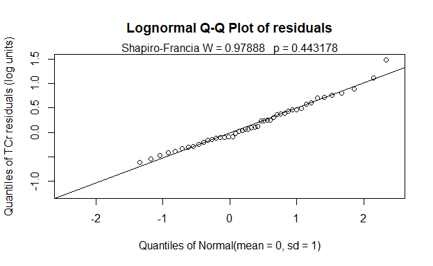

```
#>  Likelihood R2 = 0.659                     AIC = 106.3479
#>  Rescaled Likelihood R2 = 0.7143            BIC = 118.3012
#>  McFaddens R2 = 0.4206397
#>
#> Call:
#> survreg(formula = "log(TCr)", data = "dectime+discharge+sinT+cosT",
#>     dist = "gaussian")
#>
#> Coefficients:
#>  (Intercept)      dectime    discharge         sinT         cosT
#> 196.27125199  -0.09773029   0.00104809   0.21495631   0.30433249
#>
#> Scale= 0.5097264
#>
#> Loglik(model)= -46.7   Loglik(intercept only)= -80.6
#>  Chisq= 67.77 on 4 degrees of freedom, p= 6.69e-14
#> n= 63
```

```r
sinT <- with(Gales_Creek, sin(2*pi*dectime))
cosT <- with(Gales_Creek, cos(2*pi*dectime))
timeflowseas <- with(Gales_Creek,data.frame(dectime, discharge))
timeflowseas <- cbind(timeflowseas,sinT,cosT)
with(Gales_Creek, cencorreg(TCr, CrND, timeflowseas))
```

The QQ plot looks good. The sin and cos model has a lower AIC (106.3 versus the 2-variable model’s 113.5) so this is the best model of the three. The slope of -0.098 per year still maps to around a 10% decrease in concentration per year.

## Logistic Regression

The ReconLogistic dataset presents atrazine concentrations at streams across the midwestern United States. There were multiple detection limits, and a health advisory of 1 ug/L. Several characteristics of the basin at the time of sampling, including streamflow, are also recorded.

```r
data(ReconLogistic)

head(ReconLogistic,3)
```

```
#>   CORNpct SOILGP PRECIP DYPLANT FPCTL APPLIC TEMP GT_1
#> 1      15    2.9   94.5      10    97   19.0 10.2    1
#> 2      15    2.9   94.5     130    19   19.0 10.2    0
#> 3      19    2.9   94.0     284    86   25.4 10.8    0
```

We will model the above/below 1 ug/L pattern using the `GT_1` variable. The primary assumption is that there is a linear relationship between the X variables and the log(odds). Start by checking VIFs for all 6 candidate variables. The `glm` command using the `family=binomial(logit)` link function produces the equation:

```r
glm.1 <- glm(GT_1~
               APPLIC+
               CORNpct+
               SOILGP+
               PRECIP+
               DYPLANT+
               FPCTL,
             ReconLogistic,family=binomial(logit))
vif(glm.1)
```

```
#>   APPLIC  CORNpct   SOILGP   PRECIP  DYPLANT    FPCTL
#> 1.802862 1.738165 1.467392 1.550877 1.172150 1.119903
```

There is no multicollinearity between the variables, as indicated by VIF values of less than 2. Therefore the reported p-values should be trustworthy.

```r
summary(glm.1)
```

```
#>
#> Call:
#> glm(formula = GT_1 ~ APPLIC + CORNpct + SOILGP + PRECIP + DYPLANT +
#>     FPCTL, family = binomial(logit), data = ReconLogistic)
#>
#> Deviance Residuals:
#>     Min       1Q   Median       3Q      Max
#> -2.1267  -0.4117  -0.1715   0.3839   3.4336
#>
#> Coefficients:
#>              Estimate Std. Error z value Pr(>|z|)
#> (Intercept) -6.323566   1.693157  -3.735 0.000188 ***
#> APPLIC       0.017530   0.020220   0.867 0.385984
#> CORNpct      0.034572   0.023263   1.486 0.137250
#> SOILGP       0.439216   0.503541   0.872 0.383070
#> PRECIP       0.039064   0.015949   2.449 0.014315 *
#> DYPLANT     -0.016791   0.001919  -8.749  < 2e-16 ***
#> FPCTL        0.036820   0.006130   6.006  1.9e-09 ***
#> ---
#> Signif. codes:  0 '***' 0.001 '**' 0.01 '*' 0.05 '.' 0.1 ' ' 1
#>
#> (Dispersion parameter for binomial family taken to be 1)
#>
#>     Null deviance: 558.0  on 422  degrees of freedom
#> Residual deviance: 245.9  on 416  degrees of freedom
#> AIC: 259.9
#>
#> Number of Fisher Scoring iterations: 6
```

To compute the overall test of whether this model is better than no model at all, the test that all slopes are zero, first compute the null model by using a 1 instead of any X variables in the right-hand side of the equation:

```r
glm.null <- glm(GT_1~1,ReconLogistic,family=binomial(logit))

anova(glm.null,glm.1,test="Chisq")
```

```
#> Analysis of Deviance Table
#>
#> Model 1: GT_1 ~ 1
#> Model 2: GT_1 ~ APPLIC + CORNpct + SOILGP + PRECIP + DYPLANT + FPCTL
#>   Resid. Df Resid. Dev Df Deviance  Pr(>Chi)
#> 1       422      558.0
#> 2       416      245.9  6    312.1 < 2.2e-16 ***
#> ---
#> Signif. codes:  0 '***' 0.001 '**' 0.01 '*' 0.05 '.' 0.1 ' ' 1
```

The test statistic often named G equals 312.1. Compared to a chi-squared distribution with 6 degrees of freedom, the difference in the number of X variables between the two models, this statistic has a p-value of 2 x 10^-16, and so is very significant. We conclude that there is information in this model for predicting atrazine occurrence above 1 and proceed to try and find the best model. The simplest way to have the computer tell you the best logistic regression model is to use the bestglm command. But let’s try manually first and see how we do. We need to see if any of the X variables need to be transformed.

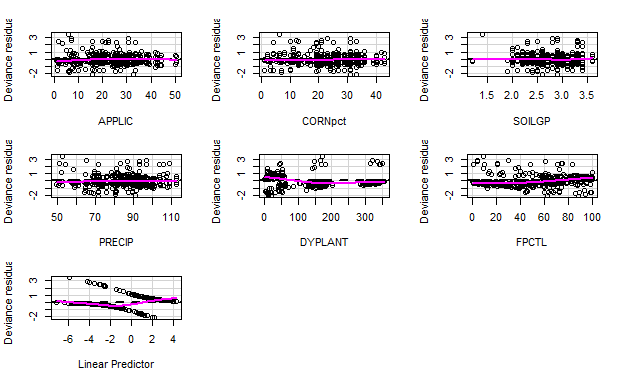

```
#>         Test stat Pr(>|Test stat|)
#> APPLIC     2.2736        0.1315939
#> CORNpct    0.9137        0.3391386
#> SOILGP     8.8183        0.0029822 **
#> PRECIP     4.2759        0.0386572 *
#> DYPLANT   12.0510        0.0005177 ***
#> FPCTL      3.4084        0.0648658 .
#> ---
#> Signif. codes:  0 '***' 0.001 '**' 0.01 '*' 0.05 '.' 0.1 ' ' 1
```

```r
residualPlots(glm.1,type="deviance")
```

It is hard to judge residuals plots with logistic regression because there are separate groups of residuals for the Y = 0 and 1 data. The smooth for DYPLANT appears curved, but is not an improvement. If `log(Dyplant)` is substituted for `Dyplant` the AIC increases, so is not a better model.

Using `glm.1`, `Applic` had the highest p-value, so we’ll drop it and see if AIC goes below 259.9.

```r
glm.3 <- glm(GT_1~
               CORNpct+
               SOILGP+
               PRECIP+
               DYPLANT+
               FPCTL,
             ReconLogistic,family=binomial(logit))
summary(glm.3)
```

```
#>
#> Call:
#> glm(formula = GT_1 ~ CORNpct + SOILGP + PRECIP + DYPLANT + FPCTL,
#>     family = binomial(logit), data = ReconLogistic)
#>
#> Deviance Residuals:
#>     Min       1Q   Median       3Q      Max
#> -2.2041  -0.4140  -0.1716   0.3764   3.4801
#>
#> Coefficients:
#>              Estimate Std. Error z value Pr(>|z|)
#> (Intercept) -6.818507   1.599850  -4.262 2.03e-05 ***
#> CORNpct      0.045965   0.019277   2.384  0.01711 *
#> SOILGP       0.509550   0.495964   1.027  0.30424
#> PRECIP       0.043378   0.015074   2.878  0.00401 **
#> DYPLANT     -0.016598   0.001876  -8.848  < 2e-16 ***
#> FPCTL        0.037835   0.005993   6.313 2.73e-10 ***
#> ---
#> Signif. codes:  0 '***' 0.001 '**' 0.01 '*' 0.05 '.' 0.1 ' ' 1
#>
#> (Dispersion parameter for binomial family taken to be 1)
#>
#>     Null deviance: 558.00  on 422  degrees of freedom
#> Residual deviance: 246.66  on 417  degrees of freedom
#> AIC: 258.66
#>
#> Number of Fisher Scoring iterations: 6
```

This 5-variable model is improved over `glm.1`. `SoilGp` remains insignificant so let’s drop that and see the effect on AIC.

```r
glm.4 <- glm(GT_1~
               CORNpct+
               PRECIP+
               DYPLANT+
               FPCTL,
             ReconLogistic,family=binomial(logit))
summary(glm.4)
```

```
#>
#> Call:
#> glm(formula = GT_1 ~ CORNpct + PRECIP + DYPLANT + FPCTL, family = binomial(logit),
#>     data = ReconLogistic)
#>
#> Deviance Residuals:
#>     Min       1Q   Median       3Q      Max
#> -2.1097  -0.4123  -0.1875   0.3781   3.3046
#>
#> Coefficients:
#>              Estimate Std. Error z value Pr(>|z|)
#> (Intercept) -5.856860   1.267119  -4.622 3.80e-06 ***
#> CORNpct      0.039045   0.017943   2.176 0.029554 *
#> PRECIP       0.050493   0.013412   3.765 0.000167 ***
#> DYPLANT     -0.016507   0.001866  -8.846  < 2e-16 ***
#> FPCTL        0.037770   0.005970   6.327 2.51e-10 ***
#> ---
#> Signif. codes:  0 '***' 0.001 '**' 0.01 '*' 0.05 '.' 0.1 ' ' 1
#>
#> (Dispersion parameter for binomial family taken to be 1)
#>
#>     Null deviance: 558.00  on 422  degrees of freedom
#> Residual deviance: 247.72  on 418  degrees of freedom
#> AIC: 257.72
#>
#> Number of Fisher Scoring iterations: 6
```

```r
bestglm(ReconLogistic,family = binomial(logit), IC = "AIC")
```

```
#> Morgan-Tatar search since family is non-gaussian.
#> AIC
#> BICq equivalent for q in (0.388676345462891, 0.914863500091258)
#> Best Model:
#>                Estimate  Std. Error   z value     Pr(>|z|)
#> (Intercept) -6.53329819 1.181212560 -5.531010 3.183926e-08
#> CORNpct      0.04814197 0.018616040  2.586048 9.708340e-03
#> DYPLANT     -0.01743824 0.002029210 -8.593611 8.427813e-18
#> FPCTL        0.03585721 0.006189977  5.792787 6.922797e-09
#> TEMP         0.50653496 0.102252080  4.953786 7.278310e-07
```

glm.4 has slopes with algebraic signs that make scientific sense, and all explanatory variables are significant at alpha = 0.05. The model can be compared to the original 6 variable model using either a partial test, or with the AIC. The partial test determines whether the two variables that were dropped add significantly to the explanatory power of the model, just as in multiple linear regression. The null hypothesis is that they do not; not rejecting the null hypothesis says to keep the simpler model.

```r
anova(glm.4, glm.1, test="Chisq")
```

```
#> Analysis of Deviance Table
#>
#> Model 1: GT_1 ~ CORNpct + PRECIP + DYPLANT + FPCTL
#> Model 2: GT_1 ~ APPLIC + CORNpct + SOILGP + PRECIP + DYPLANT + FPCTL
#>   Resid. Df Resid. Dev Df Deviance Pr(>Chi)
#> 1       418     247.72
#> 2       416     245.90  2   1.8257   0.4014
```

```r
Recon.frame = with(ReconLogistic, datadist(CORNpct, DYPLANT, FPCTL, TEMP, GT_1))
options(datadist = "Recon.frame")
lrm4 <- lrm(GT_1 ~ CORNpct + DYPLANT + FPCTL + TEMP, data = ReconLogistic)
lrm4
```

```
#> Logistic Regression Model
#>
#> lrm(formula = GT_1 ~ CORNpct + DYPLANT + FPCTL + TEMP, data = ReconLogistic)
#>
#>                        Model Likelihood      Discrimination    Rank Discrim.
#>                              Ratio Test             Indexes          Indexes
#> Obs           423    LR chi2     323.35      R2       0.729    C       0.939
#>  0            266    d.f.             4      R2(4,423)0.530    Dxy     0.877
#>  1            157    Pr(> chi2) <0.0001    R2(4,296.2)0.660    gamma   0.877
#> max |deriv| 8e-07                            Brier    0.076    tau-a   0.410
#>
#>           Coef    S.E.   Wald Z Pr(>|Z|)
#> Intercept -6.5333 1.1812 -5.53  <0.0001
#> CORNpct    0.0481 0.0186  2.59  0.0097
#> DYPLANT   -0.0174 0.0020 -8.59  <0.0001
#> FPCTL      0.0359 0.0062  5.79  <0.0001
#> TEMP       0.5065 0.1023  4.95  <0.0001
```